# Date Manipulation and Wrangling using R

### **3.5 Sorting, Reordering, Slicing, and Arranging**

- `arrange()`, `desc()`
- `slice_max()`, `slice_min()`, `top_n()`
- Ranking data and filtering top/bottom groups

Sorting and reordering data is important for finding trends, identifying extremes (top or bottom performers), and preparing tables for reporting or visualization.  
In `dplyr`, the `arrange()` function sorts datasets by one or more variables, while `desc()` allows descending (reverse) order.  
For selecting specific rows like top N or bottom N values, `slice_max()` and `slice_min()` are commonly used.

These techniques allow focusing on key records, comparing rankings across groups, and making datasets easier to review.

**🔹 Summary of Functions for Sorting and Reordering**

| **Task** | **Function** | **Purpose** |
| --- | --- | --- |
| Sort ascending order | `arrange()` | Sort rows by one or more variables (lowest to highest) |
| Sort descending order | `arrange(desc())` | Sort rows highest to lowest |
| Select top N rows by a variable | `slice_max()` | Keep top N records based on a variable |
| Select bottom N rows by a variable | `slice_min()` | Keep bottom N records based on a variable |
| Select top N rows (old method) | `top_n()` | Deprecated alternative to `slice_max()` (not recommended now) |
| Rank within groups | `mutate(rank = row_number())` | Create custom ranking inside grouped data |

➡️ Sorting and slicing help prioritize key data points and create targeted outputs for decision-making or visualization.

```r
# ....................................................
# Sorting, Reordering, Slicing, and Arranging (Breast Cancer Data)
# ....................................................

# Sorting by Screening Rate in Ascending Order
bc_sorted_rate <- breast_cancer_data %>%
  arrange(rate50_74) %>%
  select(sa3code, sa3coden, sa3name, state, year,
         part50_74, pop50_74, rate50_74, agen50_74, expct50_74)

head(bc_sorted_rate)
```

```
  sa3code sa3coden        sa3name state   year part50_74 pop50_74 rate50_74
1   90104    90104 Norfolk Island Other 201920        24      441   5.40000
2   90104    90104 Norfolk Island Other 201819        31      422   7.30000
3   90104    90104 Norfolk Island Other 201718        39      401   9.70000
4   70205    70205      Katherine    NT 201920       412     2011  20.51335
5   51002    51002   East Pilbara    WA 201920       562     1987  28.26220
6   51002    51002   East Pilbara    WA 201819       567     1918  29.55425
  agen50_74 expct50_74
1         3        220
2         3        231
3         3        219
4         3       1003
5         3        991
6         3       1051
```

```r
# Sorting by Screening Rate in Descending Order
bc_sorted_rate_desc <- breast_cancer_data %>%
  arrange(desc(rate50_74)) %>%
  select(sa3code, sa3coden, sa3name, state, year,
         part50_74, pop50_74, rate50_74, agen50_74, expct50_74)

head(bc_sorted_rate_desc)
```

```
  sa3code sa3coden                        sa3name state   year part50_74
1   90102    90102        Cocos (Keeling) Islands Other 201920        81
2   31801    31801 Charters Towers - Ayr - Ingham   Qld 201617      4628
3   60102    60102            Hobart - North East   Tas 201718      5856
4   60104    60104        Hobart - South and West   Tas 201718      3643
5   11004    11004            Tamworth - Gunnedah   NSW 201819      8426
6   31801    31801 Charters Towers - Ayr - Ingham   Qld 201718      4612
  pop50_74 rate50_74 agen50_74 expct50_74
1      101  80.20000         3         50
2     6713  68.90000         3       3692
3     8566  68.36348         3       4694
4     5331  68.34190         3       2921
5    12333  68.32168         3       6758
6     6759  68.23824         3       3703
```

```r
# Slicing Top 10 SA3s with Highest Screening Rates
bc_top_screening <- breast_cancer_data %>%
  slice_max(order_by = rate50_74, n = 10) %>%
  select(sa3code, sa3coden, sa3name, state, year,
         part50_74, pop50_74, rate50_74, agen50_74, expct50_74)

bc_top_screening
```

```
   sa3code sa3coden                        sa3name state   year part50_74
1    90102    90102        Cocos (Keeling) Islands Other 201920        81
2    31801    31801 Charters Towers - Ayr - Ingham   Qld 201617      4628
3    60102    60102            Hobart - North East   Tas 201718      5856
4    60104    60104        Hobart - South and West   Tas 201718      3643
5    11004    11004            Tamworth - Gunnedah   NSW 201819      8426
6    31801    31801 Charters Towers - Ayr - Ingham   Qld 201718      4612
7    11001    11001                       Armidale   NSW 201617      3810
8    60102    60102            Hobart - North East   Tas 201819      5881
9    31801    31801 Charters Towers - Ayr - Ingham   Qld 201819      4588
10   31801    31801 Charters Towers - Ayr - Ingham   Qld 201920      4580
   pop50_74 rate50_74 agen50_74 expct50_74
1       101  80.20000         3         50
2      6713  68.90000         3       3692
3      8566  68.36348         3       4694
4      5331  68.34190         3       2921
5     12333  68.32168         3       6758
6      6759  68.23824         3       3703
7      5602  68.00000         3       3081
8      8698  67.61016         3       4766
9      6797  67.49974         3       3724
10     6818  67.17431         3       3402
```

```r
# Slicing Bottom 5 SA3s with Lowest Screening Rates
bc_bottom_screening <- breast_cancer_data %>%
  slice_min(order_by = rate50_74, n = 5) %>%
  select(sa3code, sa3coden, sa3name, state, year,
         part50_74, pop50_74, rate50_74, agen50_74, expct50_74)

bc_bottom_screening
```

```
  sa3code sa3coden        sa3name state   year part50_74 pop50_74 rate50_74
1   90104    90104 Norfolk Island Other 201920        24      441   5.40000
2   90104    90104 Norfolk Island Other 201819        31      422   7.30000
3   90104    90104 Norfolk Island Other 201718        39      401   9.70000
4   70205    70205      Katherine    NT 201920       412     2011  20.51335
5   51002    51002   East Pilbara    WA 201920       562     1987  28.26220
  agen50_74 expct50_74
1         3        220
2         3        231
3         3        219
4         3       1003
5         3        991
```

```r
# Ranking Within Each State
bc_ranked <- breast_cancer_data %>%
  group_by(state) %>%
  arrange(desc(rate50_74), .by_group = TRUE) %>%
  mutate(screening_rank = row_number()) %>%
  select(screening_rank, rate50_74, state) %>%
  ungroup()

head(bc_ranked, n = 10)
```

```
# A tibble: 10 × 3
   screening_rank rate50_74 state
            <int>     <dbl> <chr>
 1              1      59.9 ACT
 2              2      58.8 ACT
 3              3      58.4 ACT
 4              4      58   ACT
 5              5      57.7 ACT
 6              6      57.4 ACT
 7              7      57.2 ACT
 8              8      57.1 ACT
 9              9      57.0 ACT
10             10      56.7 ACT
```

```r
# ....................................................
# Remove all temporary objects created in this chunk
# ....................................................
rm(bc_sorted_rate, bc_sorted_rate_desc, bc_top_screening, bc_bottom_screening, bc_ranked)
```

### **3.6 Reshaping and Tidy Data**

- `pivot_longer()`, `pivot_wider()`
- Wide-to-long and long-to-wide transformations
- Separating and uniting columns with `separate()` and `unite()`

In data analysis, datasets often need to be reorganized — from wide format to long format, or vice versa — to suit different types of analysis or visualization.  
The goal is to follow **Tidy Data principles** where: - Each variable forms a column - Each observation forms a row - Each type of observational unit forms a table

`dplyr` and `tidyr` provide key functions for reshaping: - `pivot_longer()` turns many columns into two columns (variable name and value). - `pivot_wider()` spreads one column into multiple columns. - `separate()` splits one column into multiple columns based on a separator. - `unite()` combines multiple columns into one.

These tools help create clean, organized datasets ready for efficient analysis and plotting.

**🔹 Summary of Functions for Reshaping and Tidy Data**

| **Task** | **Function** | **Purpose** |
| --- | --- | --- |
| Reshape wide to long | `pivot_longer()` | Collapse multiple columns into key-value pairs |
| Reshape long to wide | `pivot_wider()` | Spread key-value pairs across multiple columns |
| Split a column into multiple parts | `separate()` | Separate one column into several columns by a delimiter |
| Combine multiple columns into one | `unite()` | Merge several columns into a single column |

➡️ These reshaping techniques make it easy to transform datasets into a tidy structure for summaries, modeling, or visualization.

> ** 🔎 Regular Expression Tip for `names_pattern`**

> In `pivot_longer()`, we use a regular expression to split the column names into two components: - `part`, `pop`, `rate`, or `expct` → **measure** - `50_54`, `55_59`, etc. → **age group** The pattern `([0-9]{2}_[0-9]{2})` works as follows:

> | **Component** | **Meaning** |
> | --- | --- |
> | `[0-9]` | Match any digit (0–9) |
> | `{2}` | Exactly two digits |
> | `_` | An underscore |
> | `[0-9]{2}` | Another two digits |

> ➡️ This captures typical age formats like `50_54`, `60_64`, etc.

Original Column Name: rate50_54

```r
# ....................................................
# Reshaping, Separate and Unite Columns: Breast Cancer Data
# ....................................................

# Pivot longer by extracting measure type and age group separately
breast_cancer_long <- breast_cancer_data %>%
  pivot_longer(
    cols = starts_with("part") | starts_with("pop") | starts_with("rate") | starts_with("expct"),
    names_to = c("measure", "age_group"),
    names_pattern = "(part|pop|rate|expct)([0-9]{2}_[0-9]{2})",
    values_to = "value"
  ) %>%
  relocate(measure, age_group, .before = sa3code)

head(breast_cancer_long, n = 10)
```

```
# A tibble: 10 × 15
   measure age_group sa3code sa3coden sa3name   state   year agen50_74 agen50_69
   <chr>   <chr>       <int>    <int> <chr>     <chr>  <int>     <int>     <int>
 1 part    50_74       10102    10102 Queanbey… NSW   201617         3         2
 2 part    50_69       10102    10102 Queanbey… NSW   201617         3         2
 3 part    50_54       10102    10102 Queanbey… NSW   201617         3         2
 4 part    55_59       10102    10102 Queanbey… NSW   201617         3         2
 5 part    60_64       10102    10102 Queanbey… NSW   201617         3         2
 6 part    65_69       10102    10102 Queanbey… NSW   201617         3         2
 7 part    70_74       10102    10102 Queanbey… NSW   201617         3         2
 8 pop     50_74       10102    10102 Queanbey… NSW   201617         3         2
 9 pop     50_69       10102    10102 Queanbey… NSW   201617         3         2
10 pop     50_54       10102    10102 Queanbey… NSW   201617         3         2
# ℹ 6 more variables: agen50_54 <int>, agen55_59 <int>, agen60_64 <int>,
#   agen65_69 <int>, agen70_74 <int>, value <dbl>
```

```r
# Pivot wider to spread measures into separate columns
breast_cancer_final <- breast_cancer_long %>%
  pivot_wider(
    names_from = measure,
    values_from = value
  ) %>%
  relocate(part, pop, rate, expct, .before = sa3code)

head(breast_cancer_final, n = 5)
```

```
# A tibble: 5 × 17
  age_group  part   pop  rate expct sa3code sa3coden sa3name    state   year
  <chr>     <dbl> <dbl> <dbl> <dbl>   <int>    <int> <chr>      <chr>  <int>
1 50_74      4875  8052  60.5  4428   10102    10102 Queanbeyan NSW   201617
2 50_69      4309  7145  60.3  3929   10102    10102 Queanbeyan NSW   201617
3 50_54      1284  2251  57    1118   10102    10102 Queanbeyan NSW   201617
4 55_59      1188  1970  60.3  1046   10102    10102 Queanbeyan NSW   201617
5 60_64      1012  1625  62.3   950   10102    10102 Queanbeyan NSW   201617
# ℹ 7 more variables: agen50_74 <int>, agen50_69 <int>, agen50_54 <int>,
#   agen55_59 <int>, agen60_64 <int>, agen65_69 <int>, agen70_74 <int>
```

```r
# Separate 'age_group' into two new columns: start and end age
breast_cancer_separated <- breast_cancer_long %>%
  separate(
    col = age_group,
    into = c("age_start", "age_end"),
    sep = "_",
    convert = TRUE
  ) %>%
  select("age_start", "age_end", everything())

head(breast_cancer_separated, n = 3)
```

```
# A tibble: 3 × 16
  age_start age_end measure sa3code sa3coden sa3name    state   year agen50_74
      <int>   <int> <chr>     <int>    <int> <chr>      <chr>  <int>     <int>
1        50      74 part      10102    10102 Queanbeyan NSW   201617         3
2        50      69 part      10102    10102 Queanbeyan NSW   201617         3
3        50      54 part      10102    10102 Queanbeyan NSW   201617         3
# ℹ 7 more variables: agen50_69 <int>, agen50_54 <int>, agen55_59 <int>,
#   agen60_64 <int>, agen65_69 <int>, agen70_74 <int>, value <dbl>
```

```r
# Unite 'age_start' and 'age_end' into a single age group label
breast_cancer_united <- breast_cancer_separated %>%
  unite(
    col = age_group_combined,
    age_start, age_end,
    sep = "-",
    remove = FALSE
  )

head(breast_cancer_united, n = 3)
```

```
# A tibble: 3 × 17
  age_group_combined age_start age_end measure sa3code sa3coden sa3name    state
  <chr>                  <int>   <int> <chr>     <int>    <int> <chr>      <chr>
1 50-74                     50      74 part      10102    10102 Queanbeyan NSW
2 50-69                     50      69 part      10102    10102 Queanbeyan NSW
3 50-54                     50      54 part      10102    10102 Queanbeyan NSW
# ℹ 9 more variables: year <int>, agen50_74 <int>, agen50_69 <int>,
#   agen50_54 <int>, agen55_59 <int>, agen60_64 <int>, agen65_69 <int>,
#   agen70_74 <int>, value <dbl>
```

```r
# ....................................................
# Remove temporary objects created in this chunk
# ....................................................
rm(breast_cancer_long, breast_cancer_separated, breast_cancer_united, breast_cancer_final)
```

## **PART IV: ADVANCED WRANGLING AND INTEGRATION**

### **4.1 Date and Time data manipulation**

- `lubridate::ymd()`, `as_date()`, `format()`, `%p`, `weekdays()`
- Extracting date components: year, month, quarter

Working with dates is essential in many datasets, particularly for time-based trends, age calculations, seasonal effects, and survival analysis.  
We use the `lubridate` package to parse, extract, and manipulate dates efficiently. The details about time and date data has been presented separately.

➡️ **For full tutorials and videos:** - **YouTube (AnalyticsHub)**: [Watch Full Video](https://studio.youtube.com/video/AZjUWcakEEY/edit) - **GitHub**: [Access Here](https://github.com/HabtamuBizuayehu/Date-and-Time-Manipulation-and-Analysis_Data_insight)

**Summary of Functions for Date Handling**

| **Task** | **Function** | **Purpose** |
| --- | --- | --- |
| Parse ISO dates | `as.Date()`, `strptime()` | Read and convert raw string timestamps |
| Format date output | `format()` | Customize how dates are displayed |
| Extract components | `year()`, `month()`, `day()`, `quarter()`, `week()` | Pull year, month, day, quarter, week from dates |
| Weekday labels | `wday(label = TRUE)` | Get day of week in text form |
| Date arithmetic | `difftime()`, `-` | Calculate differences between dates |
| Logical operations | `<`, `>`, `between()` | Filter by date ranges |
| Fiscal/seasonal grouping | `case_when()` | Categorize based on seasons or financial years |

**Demonstration using Vaccination Dataset**

```r
# Convert DATE into usable R date format
vaccination <- vaccination %>%
  mutate(
    vacc_date = as.Date(strptime(date, format = "%Y-%m-%dT%H:%M:%SZ")),
    vacc_year = year(vacc_date),
    vacc_month = month(vacc_date, label = TRUE, abbr = FALSE)
  ) %>%
  select(-description, base_cost)

head(vaccination)
```

```
                  date                              patient base_cost
1 2016-04-10T09:04:48Z 30a6452c-4297-a1ac-977a-6a23237c7b46       136
2 2016-04-10T09:04:48Z 30a6452c-4297-a1ac-977a-6a23237c7b46       136
3 2016-04-10T09:04:48Z 30a6452c-4297-a1ac-977a-6a23237c7b46       136
4 2016-04-10T09:04:48Z 30a6452c-4297-a1ac-977a-6a23237c7b46       136
5 2002-10-29T19:07:21Z 34a4dcc4-35fb-6ad5-ab98-be285c586a4f       136
6 2005-11-01T19:07:21Z 34a4dcc4-35fb-6ad5-ab98-be285c586a4f       136
   vacc_date year    month vaccine_group          vacc_group3 vacc_year
1 2016-04-10 2016    April     Influenza Respiratory vaccines      2016
2 2016-04-10 2016    April     DTP group   Childhood vaccines      2016
3 2016-04-10 2016    April     Hepatitis   Childhood vaccines      2016
4 2016-04-10 2016    April Meningococcal   Childhood vaccines      2016
5 2002-10-29 2002  October     Influenza Respiratory vaccines      2002
6 2005-11-01 2005 November     Influenza Respiratory vaccines      2005
  vacc_month
1      April
2      April
3      April
4      April
5    October
6   November
```

Calculating Time Differences

```r
# Calculating Time Differences

# Convert column names to lowercase
colnames(patients) <- tolower(colnames(patients))
colnames(vaccination) <- tolower(colnames(vaccination))

# vacc_pt_merged <- left_join(patients, vaccination, by = "id" )
vacc_pt_merged <- left_join(patients, vaccination, by = c("id" = "patient"))

str (vacc_pt_merged)
```

```
'data.frame':   1619 obs. of  37 variables:
 $ id                 : chr  "30a6452c-4297-a1ac-977a-6a23237c7b46" "30a6452c-4297-a1ac-977a-6a23237c7b46" "30a6452c-4297-a1ac-977a-6a23237c7b46" "30a6452c-4297-a1ac-977a-6a23237c7b46" ...
 $ birthdate          : chr  "1994-02-06" "1994-02-06" "1994-02-06" "1994-02-06" ...
 $ deathdate          : chr  "" "" "" "" ...
 $ ssn                : chr  "999-52-8591" "999-52-8591" "999-52-8591" "999-52-8591" ...
 $ drivers            : chr  "S99996852" "S99996852" "S99996852" "S99996852" ...
 $ passport           : chr  "X47758697X" "X47758697X" "X47758697X" "X47758697X" ...
 $ prefix             : chr  "Mr." "Mr." "Mr." "Mr." ...
 $ first              : chr  "Joshua658" "Joshua658" "Joshua658" "Joshua658" ...
 $ middle             : chr  "Alvin56" "Alvin56" "Alvin56" "Alvin56" ...
 $ last               : chr  "Kunde533" "Kunde533" "Kunde533" "Kunde533" ...
 $ suffix             : logi  NA NA NA NA NA NA ...
 $ maiden             : chr  "" "" "" "" ...
 $ marital            : chr  "M" "M" "M" "M" ...
 $ race               : chr  "white" "white" "white" "white" ...
```

[output cut: 23 more lines]

```r
vacc_pt_merged %>%
  mutate(
    vacc_date = as.Date(strptime(date, format = "%Y-%m-%dT%H:%M:%SZ")),
    birthdate = as.Date(birthdate),
    days_to_vax = as.numeric(difftime(vacc_date, birthdate, units = "days")),
    weeks_to_vax = as.numeric(difftime(vacc_date, birthdate, units = "weeks")),
    months_to_vax = as.numeric(difftime(vacc_date, birthdate, units = "days")) / 30.44,
    years_to_vax = floor(as.numeric(difftime(vacc_date, birthdate, units = "days")) / 365.25)
  ) -> vacc_pt_merged

summary(vacc_pt_merged$days_to_vax)
```

```
   Min. 1st Qu.  Median    Mean 3rd Qu.    Max.
      0    2548    7742   10375   18263   36813
```

```r
summary(vacc_pt_merged$years_to_vax)
```

```
   Min. 1st Qu.  Median    Mean 3rd Qu.    Max.
   0.00    6.00   21.00   28.02   50.00  100.00
```

Extracting Date Components

```r
vacc_pt_merged <- vacc_pt_merged %>%
  mutate(
    vacc_day = day(vacc_date),
    vacc_month_num = month(vacc_date),
    vacc_month_name = month(vacc_date, label = TRUE, abbr = FALSE),
    vacc_weekday = wday(vacc_date, label = TRUE, abbr = FALSE),
    vacc_week = week(vacc_date),
    vacc_quarter = quarter(vacc_date),
    vacc_year = year(vacc_date),  # Define vacc_year first
    vacc_fy = if_else(vacc_month_num >= 7, vacc_year, vacc_year - 1),  # FY starts 1 July in Australia
    vacc_season = case_when(
      vacc_month_num %in% 12:2 ~ "Summer",
      vacc_month_num %in% 3:5  ~ "Autumn",
      vacc_month_num %in% 6:8  ~ "Winter",
      vacc_month_num %in% 9:11 ~ "Spring"
    ),
    is_weekend = wday(vacc_date) %in% c(1, 7),
    days_since_ref = floor(as.numeric(difftime(vacc_date, as.Date("2020-01-01"), units = "days")))
  )

temp <- vacc_pt_merged %>%
  select(vacc_day, vacc_month_num, vacc_month_name, vacc_weekday, vacc_week,
         vacc_quarter, vacc_year, vacc_fy, vacc_season, is_weekend, days_since_ref)

head(temp, n = 8)
```

```
  vacc_day vacc_month_num vacc_month_name vacc_weekday vacc_week vacc_quarter
1       10              4           April       Sunday        15            2
2       10              4           April       Sunday        15            2
3       10              4           April       Sunday        15            2
4       10              4           April       Sunday        15            2
5       14              4           April       Sunday        15            2
6       17              4           April       Sunday        16            2
7       29             10         October      Tuesday        44            4
8        1             11        November      Tuesday        44            4
  vacc_year vacc_fy vacc_season is_weekend days_since_ref
1      2016    2015      Summer       TRUE          -1361
2      2016    2015      Summer       TRUE          -1361
3      2016    2015      Summer       TRUE          -1361
4      2016    2015      Summer       TRUE          -1361
5      2019    2018      Summer       TRUE           -262
6      2022    2021      Summer       TRUE            837
7      2002    2002      Summer      FALSE          -6273
8      2005    2005      Summer      FALSE          -5174
```

```r
rm (temp)
```

Filtering Between Date Ranges

```r
# Calculate Age as of 31 December 2024
# str(vacc_pt_merged$birthdate)

vacc_pt_merged <- vacc_pt_merged %>%
  mutate(
    age = floor(time_length(difftime(as.Date("2024-12-31"), birthdate), unit = "years"))
  )

table (vacc_pt_merged$age)
```

```
  1   2   5   6   7  10  11  12  13  14  15  16  17  18  19  20  21  23  24  25
 46  24  64  66  34 102  38  59  21  21  34  83  18  36  18  34  48  13  12  47
 27  28  29  30  33  34  36  37  38  40  41  42  43  44  45  46  47  48  49  50
 17  30   9  38   4   7   6   8   6  20  37  16   9  17  15  13   9  21  30  15
 51  52  53  55  56  58  60  61  62  63  64  65  68  69  71  73  74  76  78  80
 13  30  16  30  30  14  12  27  49  13  26  14  14  57  15  27  15  14  12  13
 85  97 110
 12  20   1
```

```r
# Categorize into Age Groups
vacc_pt_merged <- vacc_pt_merged %>%
  mutate(
    age_group = cut(
      age,
      breaks = c(0, 9, 19, 29, 49, 100),
      labels = c("0–9", "10–19", "20–29", "30–49", "50+"),
      right = TRUE
    )
  )

table (vacc_pt_merged$age_group)
```

```
  0–9 10–19 20–29 30–49   50+
  234   430   210   256   488
```

```r
# Vaccinations only in 2022
vacc_2022 <- vacc_pt_merged %>%
  filter(vacc_date >= ymd("2022-01-01") & vacc_date <= ymd("2022-12-31"))

# Vaccinations between 2015 and 2024
vacc_1524 <- vacc_pt_merged %>%
  filter(vacc_year >= 2015 & vacc_year <= 2024)

table(vacc_1524$vacc_year)
```

```
2015 2016 2017 2018 2019 2020 2021 2022 2023 2024
 153  139  137  151  161  137  263  120  170  122
```

```r
rm(vacc_2022)
```

### **4.2 Duplicate Observations and Creating ID**

- ID Creation (if missing): paste(), substr(), as.Date(), unite()
- Detecting Duplicates: duplicated(), distinct(), n_distinct(), row_number(), count(distinct(…))
- Tagging Duplicates: row_number(), duplicated(), mutate(dup = row_number())
- Validating Duplicates: group_by() + filter(n() > 1), arrange(), subset()
- Removing Duplicates: filter(dup == 1), distinct(), summarise()
- Optional Filtering Rules: Keep first/last by date, non-missing only, domain-specific logic

Duplicate records in health or survey data can compromise the integrity of analyses. A critical first step is ensuring each individual has a consistent and unique identifier (ID). When explicit IDs are missing or unreliable, they can be constructed using combinations of variables such as names, dates of birth, and location (e.g., using `paste()`, `substr()`, or `unite()`). Once IDs are established, duplicates can be detected, reviewed, and resolved systematically through tagging (`row_number()`), visual inspection, and appropriate retention or removal strategies.

🔹 Key Aspects of Duplicate Management

| **Aspect** | **What to Address** | **Why It Matters** |
| --- | --- | --- |
| Detection Methods | Use `duplicated()`, `distinct()`, `n_distinct()`, `row_number()` by ID or keys | Helps quantify and locate potential duplicates |
| Validation | Visual/manual review using `arrange()`, `group_by()` + `filter()` | Prevents removal of legitimate but similar entries |
| Tagging Duplicates | Label using `row_number()` or `duplicated()` | Allows flexible filtering or analysis of repeats |
| Deciding What to Keep | Keep first, latest (by date), or non-missing based on rules | Avoids loss of useful or most complete records |
| Removal or Aggregation | Drop with `filter()`, or use `summarise()` to collapse duplicates | Depends on context: reporting vs. recordkeeping |
| ID Creation / Fixing | Use `mutate()` to create or correct IDs | Enables future joins and tracking |

The following table shows the summary with some data manipulation options

| **Task** | **Function / Code** | **Purpose** |
| --- | --- | --- |
| Identify blank IDs or fields | `x[x == ""] <- NA` | Convert empty strings to `NA` for proper detection |
| Count missing values | `sum(is.na(x))` | Check how many values are missing |
| Count unique observations | `count(distinct(df, id))` | Determine the number of unique records |
| Generate row numbers per group | `group_by(id) %>% mutate(dup = row_number())` | Label duplicates within each ID |
| Check duplication status | `table(df$dup)` or `sum(dup >= 2)` | Summarise duplication pattern |
| Subset for review | `subset(df, dup == 2)` | View specific duplicates for manual inspection |
| Filter duplicated individuals | `filter(n() > 1)` | Extract only duplicated IDs |
| Remove duplicates | `filter(!(dup >= 2))` | Keep only the first instance per group (if needed) |
| Clean temporary object | `rm()` | Remove intermediate datasets from environment |

This setup ensures duplicates are clearly identified, reviewed, and removed where appropriate.

```r
patients <- patients %>%
  mutate(
    birthdate = as.Date(birthdate),
    id_text = paste0(substr(first, 1, 4), "|", substr(last, 1, 4), "|", birthdate)
  )
# Preview new ID
head(patients$id_text, n = 3)
```

```
[1] "Josh|Kund|1994-02-06" "Benn|Eber|1968-08-06" "Hunt|Gerl|2008-12-21"
```

```r
# --- Step 2: Create random numeric ID per individual ---
set.seed(1234)  # for reproducibility
patients <- patients %>%
  mutate(id_num = sample(100000:999999, n(), replace = FALSE))

# Preview both ID columns
patients %>%
  select(first, last, birthdate, id_text, id_num) %>%
  head(5)
```

```
      first          last  birthdate              id_text id_num
1 Joshua658      Kunde533 1994-02-06 Josh|Kund|1994-02-06 861679
2 Bennie663      Ebert178 1968-08-06 Benn|Eber|1968-08-06 730677
3 Hunter736    Gerlach374 2008-12-21 Hunt|Gerl|2008-12-21 404107
4 Carlyn477 Williamson769 1994-01-27 Carl|Will|1994-01-27 395845
5   Robin66  Gleichner915 2019-07-27 Robi|Glei|2019-07-27 226054
```

```r
# ....................................................
# Clean-up if needed
# ....................................................
# rm(id_text, id_num) # optional if you store externally

table (patients$race)
```

```
 asian  black native  other  white
     8      6      1      3     88
```

```r
otherrace <- patients %>%
  filter(race != "white")

patients <- rbind(patients, otherrace)

# Count total and unique records
n_total <- nrow(patients)
n_unique <- n_distinct(patients$id_text)
message(glue::glue("Total records: {n_total}, Unique IDs: {n_unique}"))
```

```
Total records: 124, Unique IDs: 106
```

```r
# Tag duplicates using row_number()
patients <- patients %>%
  arrange(id_text) %>%
  group_by(id_text) %>%
  mutate(dup = row_number()) %>%
  ungroup()
# Count number of true duplicates
table(patients$dup)
```

```
  1   2
106  18
```

```r
print(sum(patients$dup >= 2))
```

```
[1] 18
```

```r
# Keep only records from individuals who have duplicates
duplicates <- patients %>%
  group_by(id_text) %>%
  filter(n() >= 2) %>%
  select(id_text, id_num, race, marital, gender, birthdate) %>%
  ungroup()

# Preview records from duplicated individuals
head(duplicates)
```

```
# A tibble: 6 × 6
  id_text              id_num race  marital gender birthdate
  <chr>                 <int> <chr> <chr>   <chr>  <date>
1 Alen|Gusi|1927-03-20 361202 other M       F      1927-03-20
2 Alen|Gusi|1927-03-20 361202 other M       F      1927-03-20
3 Bert|Alem|1983-05-07 513589 black M       F      1983-05-07
4 Bert|Alem|1983-05-07 513589 black M       F      1983-05-07
5 Blan|Rein|1951-11-22 465318 asian S       F      1951-11-22
6 Blan|Rein|1951-11-22 465318 asian S       F      1951-11-22
```

```r
rm(duplicates, n_total, n_unique)
```

### **4.3 Merging (Joining) and Appending Datasets**

- `left_join()`, `right_join()`, `inner_join()`, `full_join()`
- `semi_join()` and `anti_join()`
- `bind_rows()`, `rbind()` , `bind_cols()` and `cbind()`

When analyzing real-world datasets, it’s often necessary to **merge** or **append** multiple datasets.  
This could involve matching rows based on common identifiers, appending additional cases, or combining variables side-by-side.

We can **join**, **bind**, or **filter** datasets efficiently using `dplyr` and base R techniques.

**Brief Descriptions**

- **left_join()**: Keep all records from the left (main) table; bring matching records from the right table.
- **right_join()**: Keep all records from the right table; bring matching records from the left.
- **inner_join()**: Keep only rows where keys match in both tables.
- **full_join()**: Keep all records from both tables; missing matches filled with `NA`.
- **semi_join()**: Keep rows from the left table where a match exists in the right.
- **anti_join()**: Keep only rows from the left table that **don’t** match the right.

➡️ `bind_rows()` and `rbind()` are used for **stacking** datasets.  
➡️ `bind_cols()` and `cbind()` are used for **attaching new columns** horizontally.

**Summary Table: Key Functions for Joining and Appending**

| **Task** | **Function** | **Purpose** |
| --- | --- | --- |
| Merge by common key | `left_join()`, `right_join()`, `inner_join()`, `full_join()` | Merge datasets using common variables |
| Filter matching rows | `semi_join()` | Keep rows from left table that have matches in right table |
| Filter non-matching rows | `anti_join()` | Keep rows from left table with no match in right table |
| Row-wise append | `bind_rows()` | Stack two datasets vertically (must have same columns) |
| Column-wise append | `bind_cols()` | Add columns side-by-side (matching by row position) |
| Basic base R row bind | `rbind()` | Append rows (base R equivalent to `bind_rows`) |
| Basic base R column bind | `cbind()` | Append columns (base R equivalent to `bind_cols`) |
| Join a table to itself | Self-join | Analyze relationships within a single dataset (e.g., hierarchy) |

**Important Reminders** - Joins (`left_join`, etc.) match based on a **key** (column/s). - `bind_rows()` assumes **same column names and types**. - `bind_cols()` assumes **same number of rows**. - `rbind()` and `cbind()` are **base R** methods but `dplyr::bind_*()` are more flexible. —

**Demonstrating Different Types of Joins with Brief Descriptions**

**Standardizing variable Names**

Before performing joins, it is essential to ensure column names match in both datasets.  
This avoids errors caused by case differences or inconsistent naming.

```r
# ......................................
# Full Join: Keep everything from both datasets
# ......................................
vacc_full_join <- full_join(
  patients,
  vaccination,
  by = c("id" = "patient")
)

head(vacc_full_join, n = 3)
```

```
                                    id  birthdate deathdate         ssn
1 30a6452c-4297-a1ac-977a-6a23237c7b46 1994-02-06           999-52-8591
2 30a6452c-4297-a1ac-977a-6a23237c7b46 1994-02-06           999-52-8591
3 30a6452c-4297-a1ac-977a-6a23237c7b46 1994-02-06           999-52-8591
    drivers   passport prefix     first  middle     last suffix maiden marital
1 S99996852 X47758697X    Mr. Joshua658 Alvin56 Kunde533     NA              M
2 S99996852 X47758697X    Mr. Joshua658 Alvin56 Kunde533     NA              M
3 S99996852 X47758697X    Mr. Joshua658 Alvin56 Kunde533     NA              M
   race   ethnicity gender                birthplace          address      city
1 white nonhispanic      M Boston  Massachusetts  US 811 Kihn Viaduct Braintree
2 white nonhispanic      M Boston  Massachusetts  US 811 Kihn Viaduct Braintree
3 white nonhispanic      M Boston  Massachusetts  US 811 Kihn Viaduct Braintree
          state         county  fips  zip      lat      lon healthcare_expenses
1 Massachusetts Norfolk County 25021 2184 42.21114 -71.0458            56904.96
2 Massachusetts Norfolk County 25021 2184 42.21114 -71.0458            56904.96
3 Massachusetts Norfolk County 25021 2184 42.21114 -71.0458            56904.96
  healthcare_coverage income                 date
1            18019.99 100511 2016-04-10T09:04:48Z
2            18019.99 100511 2016-04-10T09:04:48Z
3            18019.99 100511 2016-04-10T09:04:48Z
                             encounter code
1 0b03e41b-06a6-66fa-b972-acc5a83b134a  140
2 0b03e41b-06a6-66fa-b972-acc5a83b134a  113
3 0b03e41b-06a6-66fa-b972-acc5a83b134a   43
                                                   description base_cost
1           Influenza  seasonal  injectable  preservative free       136
2 Td (adult)  5 Lf tetanus toxoid  preservative free  adsorbed       136
3                                                 Hep B  adult       136
```

```r
# ......................................
# Left Join: Keep all patients, add vaccination if available
# ......................................
vacc_left_join <- left_join(
  patients,
  vaccination,
  by = c("id" = "patient")
)

head(vacc_left_join, n = 3)
```

```
                                    id  birthdate deathdate         ssn
1 30a6452c-4297-a1ac-977a-6a23237c7b46 1994-02-06           999-52-8591
2 30a6452c-4297-a1ac-977a-6a23237c7b46 1994-02-06           999-52-8591
3 30a6452c-4297-a1ac-977a-6a23237c7b46 1994-02-06           999-52-8591
    drivers   passport prefix     first  middle     last suffix maiden marital
1 S99996852 X47758697X    Mr. Joshua658 Alvin56 Kunde533     NA              M
2 S99996852 X47758697X    Mr. Joshua658 Alvin56 Kunde533     NA              M
3 S99996852 X47758697X    Mr. Joshua658 Alvin56 Kunde533     NA              M
   race   ethnicity gender                birthplace          address      city
1 white nonhispanic      M Boston  Massachusetts  US 811 Kihn Viaduct Braintree
2 white nonhispanic      M Boston  Massachusetts  US 811 Kihn Viaduct Braintree
3 white nonhispanic      M Boston  Massachusetts  US 811 Kihn Viaduct Braintree
          state         county  fips  zip      lat      lon healthcare_expenses
1 Massachusetts Norfolk County 25021 2184 42.21114 -71.0458            56904.96
2 Massachusetts Norfolk County 25021 2184 42.21114 -71.0458            56904.96
3 Massachusetts Norfolk County 25021 2184 42.21114 -71.0458            56904.96
  healthcare_coverage income                 date
1            18019.99 100511 2016-04-10T09:04:48Z
2            18019.99 100511 2016-04-10T09:04:48Z
3            18019.99 100511 2016-04-10T09:04:48Z
                             encounter code
1 0b03e41b-06a6-66fa-b972-acc5a83b134a  140
2 0b03e41b-06a6-66fa-b972-acc5a83b134a  113
3 0b03e41b-06a6-66fa-b972-acc5a83b134a   43
                                                   description base_cost
1           Influenza  seasonal  injectable  preservative free       136
2 Td (adult)  5 Lf tetanus toxoid  preservative free  adsorbed       136
3                                                 Hep B  adult       136
```

```r
# ......................................
# Right Join: Keep all vaccinations, add patients if available
# ......................................
vacc_right_join <- right_join(
  patients,
  vaccination,
  by = c("id" = "patient")
)

head(vacc_right_join, n = 3)
```

```
                                    id  birthdate deathdate         ssn
1 30a6452c-4297-a1ac-977a-6a23237c7b46 1994-02-06           999-52-8591
2 30a6452c-4297-a1ac-977a-6a23237c7b46 1994-02-06           999-52-8591
3 30a6452c-4297-a1ac-977a-6a23237c7b46 1994-02-06           999-52-8591
    drivers   passport prefix     first  middle     last suffix maiden marital
1 S99996852 X47758697X    Mr. Joshua658 Alvin56 Kunde533     NA              M
2 S99996852 X47758697X    Mr. Joshua658 Alvin56 Kunde533     NA              M
3 S99996852 X47758697X    Mr. Joshua658 Alvin56 Kunde533     NA              M
   race   ethnicity gender                birthplace          address      city
1 white nonhispanic      M Boston  Massachusetts  US 811 Kihn Viaduct Braintree
2 white nonhispanic      M Boston  Massachusetts  US 811 Kihn Viaduct Braintree
3 white nonhispanic      M Boston  Massachusetts  US 811 Kihn Viaduct Braintree
          state         county  fips  zip      lat      lon healthcare_expenses
1 Massachusetts Norfolk County 25021 2184 42.21114 -71.0458            56904.96
2 Massachusetts Norfolk County 25021 2184 42.21114 -71.0458            56904.96
3 Massachusetts Norfolk County 25021 2184 42.21114 -71.0458            56904.96
  healthcare_coverage income                 date
1            18019.99 100511 2016-04-10T09:04:48Z
2            18019.99 100511 2016-04-10T09:04:48Z
3            18019.99 100511 2016-04-10T09:04:48Z
                             encounter code
1 0b03e41b-06a6-66fa-b972-acc5a83b134a  140
2 0b03e41b-06a6-66fa-b972-acc5a83b134a  113
3 0b03e41b-06a6-66fa-b972-acc5a83b134a   43
                                                   description base_cost
1           Influenza  seasonal  injectable  preservative free       136
2 Td (adult)  5 Lf tetanus toxoid  preservative free  adsorbed       136
3                                                 Hep B  adult       136
```

```r
# ......................................
# Inner Join: Keep only matched patients and vaccinations
# ......................................
vacc_inner_join <- inner_join(
  patients,
  vaccination,
  by = c("id" = "patient"))

head(vacc_inner_join, n = 3)
```

```
                                    id  birthdate deathdate         ssn
1 30a6452c-4297-a1ac-977a-6a23237c7b46 1994-02-06           999-52-8591
2 30a6452c-4297-a1ac-977a-6a23237c7b46 1994-02-06           999-52-8591
3 30a6452c-4297-a1ac-977a-6a23237c7b46 1994-02-06           999-52-8591
    drivers   passport prefix     first  middle     last suffix maiden marital
1 S99996852 X47758697X    Mr. Joshua658 Alvin56 Kunde533     NA              M
2 S99996852 X47758697X    Mr. Joshua658 Alvin56 Kunde533     NA              M
3 S99996852 X47758697X    Mr. Joshua658 Alvin56 Kunde533     NA              M
   race   ethnicity gender                birthplace          address      city
1 white nonhispanic      M Boston  Massachusetts  US 811 Kihn Viaduct Braintree
2 white nonhispanic      M Boston  Massachusetts  US 811 Kihn Viaduct Braintree
3 white nonhispanic      M Boston  Massachusetts  US 811 Kihn Viaduct Braintree
          state         county  fips  zip      lat      lon healthcare_expenses
1 Massachusetts Norfolk County 25021 2184 42.21114 -71.0458            56904.96
2 Massachusetts Norfolk County 25021 2184 42.21114 -71.0458            56904.96
3 Massachusetts Norfolk County 25021 2184 42.21114 -71.0458            56904.96
  healthcare_coverage income                 date
1            18019.99 100511 2016-04-10T09:04:48Z
2            18019.99 100511 2016-04-10T09:04:48Z
3            18019.99 100511 2016-04-10T09:04:48Z
                             encounter code
1 0b03e41b-06a6-66fa-b972-acc5a83b134a  140
2 0b03e41b-06a6-66fa-b972-acc5a83b134a  113
3 0b03e41b-06a6-66fa-b972-acc5a83b134a   43
                                                   description base_cost
1           Influenza  seasonal  injectable  preservative free       136
2 Td (adult)  5 Lf tetanus toxoid  preservative free  adsorbed       136
3                                                 Hep B  adult       136
```

```r
# ......................................
# Semi Join: Keep only patients that have a vaccination match
# (Only patient columns are kept)
# ......................................

vacc_semi_join <- semi_join(
  patients,
  vaccination,
  by = c("id" = "patient"))

head(vacc_semi_join, n = 3)
```

```
                                    id  birthdate  deathdate         ssn
1 30a6452c-4297-a1ac-977a-6a23237c7b46 1994-02-06            999-52-8591
2 34a4dcc4-35fb-6ad5-ab98-be285c586a4f 1968-08-06 2009-12-11 999-75-3953
3 7179458e-d6e3-c723-2530-d4acfe1c2668 2008-12-21            999-70-1925
    drivers   passport prefix     first      middle       last suffix maiden
1 S99996852 X47758697X    Mr. Joshua658     Alvin56   Kunde533     NA
2 S99993577 X28173268X    Mr. Bennie663               Ebert178     NA
3                             Hunter736 Mckinley734 Gerlach374     NA
  marital  race   ethnicity gender                  birthplace
1       M white nonhispanic      M   Boston  Massachusetts  US
2       D white nonhispanic      M Chicopee  Massachusetts  US
3         white nonhispanic      M  Spencer  Massachusetts  US
                      address         city         state          county  fips
1            811 Kihn Viaduct    Braintree Massachusetts  Norfolk County 25021
2 975 Pfannerstill Throughway    Braintree Massachusetts  Norfolk County 25021
3             548 Heller Lane Mattapoisett Massachusetts Plymouth County    NA
   zip      lat       lon healthcare_expenses healthcare_coverage income
1 2184 42.21114 -71.04580            56904.96            18019.99 100511
2 2184 42.25542 -70.97102           124024.12             1075.06  49737
3    0 41.64829 -70.85062            45645.06             6154.94 133816
```

```r
# ......................................
# Anti Join: Keep only patients that do not have a vaccination match
# ......................................
vacc_anti_join <- anti_join(
  patients,
  vaccination,
  by = c("id" = "patient"))

head(vacc_anti_join, n = 3)
```

```
 [1] id                  birthdate           deathdate
 [4] ssn                 drivers             passport
 [7] prefix              first               middle
[10] last                suffix              maiden
[13] marital             race                ethnicity
[16] gender              birthplace          address
[19] city                state               county
[22] fips                zip                 lat
[25] lon                 healthcare_expenses healthcare_coverage
[28] income
<0 rows> (or 0-length row.names)
```

```r
# ......................................
# Remove temporary datasets
# ......................................
rm(vacc_left_join, vacc_right_join, vacc_inner_join, vacc_full_join, vacc_semi_join, vacc_anti_join)
```

**Appending (Binding) DataFrames: Rows and Columns**

```r
# Binding Rows Together (bind_rows): Combine NSW, WA, and Others into one dataset

bc_combined_rows <- bind_rows(
  breast_cancer_NSW,
  breast_cancer_WA,
  breast_cancer_others
)

# Check result
head(bc_combined_rows, n = 3)
```

```
  sa3code sa3coden    sa3name state   year part50_74 pop50_74 rate50_74
1   10102    10102 Queanbeyan   NSW 201617      4875     8052  60.50000
2   10102    10102 Queanbeyan   NSW 201718      5048     8309  60.75961
3   10102    10102 Queanbeyan   NSW 201819      5276     8588  61.43839
  agen50_74 expct50_74 part50_69 pop50_69 rate50_69 agen50_69 expct50_69
1         3       4428      4309     7145  60.30000         2       3929
2         3       4553      4448     7338  60.62238         2       4013
3         3       4706      4629     7548  61.33203         2       4113
  part50_54 pop50_54 rate50_54 agen50_54 expct50_54 part55_59 pop55_59
1      1284     2251  57.00000         1       1118      1188     1970
2      1285     2306  55.72035         1       1143      1260     2030
3      1375     2342  58.70977         1       1166      1252     2093
  rate55_59 agen55_59 expct55_59 part60_64 pop60_64 rate60_64 agen60_64
1  60.30000         4       1046      1012     1625  62.30000         5
2  62.09035         4       1069      1048     1646  63.69947         5
3  59.81504         4       1098      1105     1689  65.43657         5
  expct60_64 part65_69 pop65_69 rate65_69 agen65_69 expct65_69 part70_74
1        950       826     1300  63.50000         6        781       566
2        953       855     1357  63.02558         6        812       600
3        967       898     1426  63.00429         6        849       647
  pop70_74 rate70_74 agen70_74 expct70_74
1      907  62.40000         7        498
2      971  61.79725         7        541
3     1040  62.21032         7        585
```

```r
# Confirm number of rows
nrow(bc_combined_rows)
```

```
[1] 1364
```

```r
# Binding Columns Together (bind_cols): Combine Participation Data with SA3 metadata
# (needs same number of rows)

bc_combined_cols <- bind_cols(
  participation,
  breast_cancer_SA3_info )
# Check result
head(bc_combined_cols, n = 3)
```

```
    year part50_74 pop50_74 rate50_74 agen50_74 expct50_74 part50_69 pop50_69
1 201617      4875     8052  60.50000         3       4428      4309     7145
2 201718      5048     8309  60.75961         3       4553      4448     7338
3 201819      5276     8588  61.43839         3       4706      4629     7548
  rate50_69 agen50_69 expct50_69 part50_54 pop50_54 rate50_54 agen50_54
1  60.30000         2       3929      1284     2251  57.00000         1
2  60.62238         2       4013      1285     2306  55.72035         1
3  61.33203         2       4113      1375     2342  58.70977         1
  expct50_54 part55_59 pop55_59 rate55_59 agen55_59 expct55_59 part60_64
1       1118      1188     1970  60.30000         4       1046      1012
2       1143      1260     2030  62.09035         4       1069      1048
3       1166      1252     2093  59.81504         4       1098      1105
  pop60_64 rate60_64 agen60_64 expct60_64 part65_69 pop65_69 rate65_69
1     1625  62.30000         5        950       826     1300  63.50000
2     1646  63.69947         5        953       855     1357  63.02558
3     1689  65.43657         5        967       898     1426  63.00429
  agen65_69 expct65_69 part70_74 pop70_74 rate70_74 agen70_74 expct70_74
1         6        781       566      907  62.40000         7        498
2         6        812       600      971  61.79725         7        541
3         6        849       647     1040  62.21032         7        585
  sa3code sa3coden    sa3name state
1   10102    10102 Queanbeyan   NSW
2   10102    10102 Queanbeyan   NSW
3   10102    10102 Queanbeyan   NSW
```

```r
# Appending Rows Using Base R rbind()
# (Equivalent to bind_rows but simpler cases, needs identical columns)
bc_combined_rbind <- rbind(
  breast_cancer_NSW,
  breast_cancer_WA
)

# Check result
head(bc_combined_rbind, n = 3)
```

```
  sa3code sa3coden    sa3name state   year part50_74 pop50_74 rate50_74
1   10102    10102 Queanbeyan   NSW 201617      4875     8052  60.50000
2   10102    10102 Queanbeyan   NSW 201718      5048     8309  60.75961
3   10102    10102 Queanbeyan   NSW 201819      5276     8588  61.43839
  agen50_74 expct50_74 part50_69 pop50_69 rate50_69 agen50_69 expct50_69
1         3       4428      4309     7145  60.30000         2       3929
2         3       4553      4448     7338  60.62238         2       4013
3         3       4706      4629     7548  61.33203         2       4113
  part50_54 pop50_54 rate50_54 agen50_54 expct50_54 part55_59 pop55_59
1      1284     2251  57.00000         1       1118      1188     1970
2      1285     2306  55.72035         1       1143      1260     2030
3      1375     2342  58.70977         1       1166      1252     2093
  rate55_59 agen55_59 expct55_59 part60_64 pop60_64 rate60_64 agen60_64
1  60.30000         4       1046      1012     1625  62.30000         5
2  62.09035         4       1069      1048     1646  63.69947         5
3  59.81504         4       1098      1105     1689  65.43657         5
  expct60_64 part65_69 pop65_69 rate65_69 agen65_69 expct65_69 part70_74
1        950       826     1300  63.50000         6        781       566
2        953       855     1357  63.02558         6        812       600
3        967       898     1426  63.00429         6        849       647
  pop70_74 rate70_74 agen70_74 expct70_74
1      907  62.40000         7        498
2      971  61.79725         7        541
3     1040  62.21032         7        585
```

```r
# Appending Columns Using Base R cbind()
# (Simple column binding, assumes same number of rows)

bc_combined_cbind <- cbind(
  participation,
  breast_cancer_SA3_info)

# Check result
head(bc_combined_cbind, n = 3)
```

```
    year part50_74 pop50_74 rate50_74 agen50_74 expct50_74 part50_69 pop50_69
1 201617      4875     8052  60.50000         3       4428      4309     7145
2 201718      5048     8309  60.75961         3       4553      4448     7338
3 201819      5276     8588  61.43839         3       4706      4629     7548
  rate50_69 agen50_69 expct50_69 part50_54 pop50_54 rate50_54 agen50_54
1  60.30000         2       3929      1284     2251  57.00000         1
2  60.62238         2       4013      1285     2306  55.72035         1
3  61.33203         2       4113      1375     2342  58.70977         1
  expct50_54 part55_59 pop55_59 rate55_59 agen55_59 expct55_59 part60_64
1       1118      1188     1970  60.30000         4       1046      1012
2       1143      1260     2030  62.09035         4       1069      1048
3       1166      1252     2093  59.81504         4       1098      1105
  pop60_64 rate60_64 agen60_64 expct60_64 part65_69 pop65_69 rate65_69
1     1625  62.30000         5        950       826     1300  63.50000
2     1646  63.69947         5        953       855     1357  63.02558
3     1689  65.43657         5        967       898     1426  63.00429
  agen65_69 expct65_69 part70_74 pop70_74 rate70_74 agen70_74 expct70_74
1         6        781       566      907  62.40000         7        498
2         6        812       600      971  61.79725         7        541
3         6        849       647     1040  62.21032         7        585
  sa3code sa3coden    sa3name state
1   10102    10102 Queanbeyan   NSW
2   10102    10102 Queanbeyan   NSW
3   10102    10102 Queanbeyan   NSW
```

```r
# Important Notes:
# - bind_rows() can handle different column orders safely
# - rbind() requires identical column names and order
# - bind_cols() simply pastes side-by-side, no matching by keys
# - cbind() assumes same number of rows

# ....................................................
# Remove all temporary objects created in this chunk
# ....................................................
rm(
  breast_cancer_NSW, breast_cancer_WA, breast_cancer_others, participation, breast_cancer_SA3_info,
  bc_combined_rows, bc_combined_cols, bc_combined_rbind, bc_combined_cbind
)
```

### **4.4 Missing Value Identification and Imputations**

**A. Identifying Missing Values**

- is.na(), anyNA(), sum(is.na(x)), colSums() – detect/count missing values
- complete.cases() – filter complete rows
- Convert blanks to NA: x[x == ““] <- NA

**B. Handling Missing Values**

- Basic Removal/Replacement: na.omit(), replace_na() (tidyr), ifelse()
- Forward/Backward Fill: fill() (tidyr) with .direction = “down” / “up”
- Statistical Imputation:

-Simple: mean/median imputation

-Multiple: mice::mice()()

-**Advanced**: Hmisc::aregImpute, missForest, Amelia, zoo::na.fill

Missing data is a common issue in real-world datasets. In R, handling missing values properly is essential to ensure the integrity of analyses and avoid misleading results.

This section covers how to **identify**, **clean**, and **impute** missing values using base R and tidyverse tools. Techniques range from basic filtering to advanced imputation models.

➡️ Missing values are typically represented as `NA` in R. Empty strings (e.g., `""`) or special codes (e.g., `-99`, `"missing"`) may also indicate missingness and need conversion before analysis.

🔹 Summary of Functions for Handling Missing Values

| **Task** | **Function** / **Code** | **Purpose** |
| --- | --- | --- |
| Detect missing values | `is.na(x)`, `anyNA(x)`, `sum(is.na(x))` | Identify/count missing values |
| Missing per column | `colSums(is.na(df))` | Count NAs per column |
| Filter complete rows | `complete.cases(df)` | Keep only rows without any missing values |
| Convert blanks to `NA` | `x[x == ""] <- NA` | Convert empty strings to missing values |
| Remove missing rows | `na.omit(df)` | Remove rows with any missing value |
| Replace missing values | `replace_na(df, list(...))`, `ifelse(is.na(x), ...)` | Impute or replace NA with custom logic |
| Forward/backward fill | `fill(df, .direction = "down" / "up")` | Fill NA using nearby values |
| Mean/median imputation | `x[is.na(x)] <- mean(x, na.rm = TRUE)` | Replace NA with summary statistic |
| Multiple imputation | `mice::mice(df)` | Create multiple imputed datasets using chained equations |
| Advanced imputation | `Hmisc::aregImpute`, `missForest`, `Amelia`, `zoo::na.fill()` | Specialized techniques for complex imputations |

📚 **Further Learning and Resources**

Additional tutorials, demonstrations, and datasets are available on:

- **YouTube Channel – AnalyticsHub**  
  https://studio.youtube.com/channel/UCLVKP0g8GvHhOh0kn20T8eg/videos/upload?filter=%5B%5D&sort=%7B%22columnType%22%3A%22date%22%2C%22sortOrder%22%3A%22DESCENDING%22%7D
- **GitHub Repository**  
  https://github.com/HabtamuBizuayehu?tab=repositories

[output not shown]

[output cut: 27 more lines]

```r
# Summarise missing values across all columns
missing_summary <- colSums(is.na(visits_all))
print(missing_summary[missing_summary > 0])
```

```
          deathdate             drivers            passport              prefix
                 40                   4                  12                   8
             middle              suffix              maiden             marital
                  4                  40                  28                  16
               race                fips                 zip healthcare_coverage
                 20                  12                  12                   4
             income
                 20
```

```r
# Total number of missing cells
total_missing <- sum(is.na(visits_all))
cat("Total missing values in dataset:", total_missing, "\n")
```

```
Total missing values in dataset: 220
```

```r
# Count of individuals with at least one missing value
n_missing_individuals <- sum(!complete.cases(visits_all))
cat("Number of individuals with at least one missing value:", n_missing_individuals, "\n")
```

```
Number of individuals with at least one missing value: 40
```

```r
# Sort records by patient ID and visit number
visits_all <- visits_all %>%
  arrange(id_text, visit)

# View rows with any missing values
missing_rows <- visits_all %>%
  filter(!complete.cases(.))
head(missing_rows, n = 12) %>% select(id_text, race, income, passport)
```

```
                id_text  race income   passport
1  Anit|Sánc|1960-05-07 white  61016  X9157439X
2  Anit|Sánc|1960-05-07  <NA>     NA  X9157439X
3  Anit|Sánc|1960-05-07 white     NA  X9157439X
4  Anit|Sánc|1960-05-07  <NA>  60016  X9157439X
5  Aure|Weis|2003-11-12 white   8752 X17586296X
6  Aure|Weis|2003-11-12  <NA>     NA X17586296X
7  Aure|Weis|2003-11-12 white     NA X17586296X
8  Aure|Weis|2003-11-12  <NA>   7752 X17586296X
9  Cars|Litt|2012-09-02 white  71169       <NA>
10 Cars|Litt|2012-09-02  <NA>     NA       <NA>
11 Cars|Litt|2012-09-02  <NA>  70169       <NA>
12 Cars|Litt|2012-09-02 white     NA       <NA>
```

```r
# Impute passport with "UNKNOWN"
df_passport <- visits_all %>%
  mutate(passport_imputed = replace_na(passport, "UNKNOWN")) %>%
  filter(is.na(passport)) %>%
  select(id, id_text, visit, passport, passport_imputed)

head(df_passport, n = 12)
```

```
                                     id              id_text visit passport
1  dc323bce-e583-d903-303e-9c865bc87e67 Cars|Litt|2012-09-02     1     <NA>
2  dc323bce-e583-d903-303e-9c865bc87e67 Cars|Litt|2012-09-02     2     <NA>
3  dc323bce-e583-d903-303e-9c865bc87e67 Cars|Litt|2012-09-02     3     <NA>
4  dc323bce-e583-d903-303e-9c865bc87e67 Cars|Litt|2012-09-02     4     <NA>
5  da7b1f55-c782-544f-ba8c-fe69d519dc85 Doll|Fran|2008-10-04     1     <NA>
6  da7b1f55-c782-544f-ba8c-fe69d519dc85 Doll|Fran|2008-10-04     2     <NA>
7  da7b1f55-c782-544f-ba8c-fe69d519dc85 Doll|Fran|2008-10-04     3     <NA>
8  da7b1f55-c782-544f-ba8c-fe69d519dc85 Doll|Fran|2008-10-04     4     <NA>
9  e335de09-0994-4111-3c15-6edcc17ae4bc Jimm|Doyl|2005-04-25     1     <NA>
10 e335de09-0994-4111-3c15-6edcc17ae4bc Jimm|Doyl|2005-04-25     2     <NA>
11 e335de09-0994-4111-3c15-6edcc17ae4bc Jimm|Doyl|2005-04-25     3     <NA>
12 e335de09-0994-4111-3c15-6edcc17ae4bc Jimm|Doyl|2005-04-25     4     <NA>
   passport_imputed
1           UNKNOWN
2           UNKNOWN
3           UNKNOWN
4           UNKNOWN
5           UNKNOWN
6           UNKNOWN
7           UNKNOWN
8           UNKNOWN
9           UNKNOWN
10          UNKNOWN
11          UNKNOWN
12          UNKNOWN
```

```r
# Sort records by patient ID and visit number (to prepare for forward/backward fill)
visits_all <- visits_all %>%
  arrange(id_text, visit)

# Preview sorted data (tail)
tail(visits_all %>% select(id_text, visit, race, income), n = 12)
```

```
                id_text visit  race income
29 Jimm|Doyl|2005-04-25     1 white 198522
30 Jimm|Doyl|2005-04-25     2  <NA>     NA
31 Jimm|Doyl|2005-04-25     3  <NA> 197522
32 Jimm|Doyl|2005-04-25     4 white     NA
33 Mari|Lind|1966-06-23     1 white 178323
34 Mari|Lind|1966-06-23     2  <NA>     NA
35 Mari|Lind|1966-06-23     3 white     NA
36 Mari|Lind|1966-06-23     4  <NA> 177323
37 Tamb|Bali|1953-05-10     1 white 140772
38 Tamb|Bali|1953-05-10     2  <NA>     NA
39 Tamb|Bali|1953-05-10     3 white     NA
40 Tamb|Bali|1953-05-10     4  <NA> 139772
```

```r
# Forward fill missing race values within each patient (downward)
visits_all <- visits_all %>%
  group_by(id_text) %>%
  mutate(race_forward = race) %>%
  fill(race_forward, .direction = "down") %>%
  ungroup()

# Preview forward-filled race values (head)
head(visits_all %>% select(id_text, visit, race, race_forward), n = 12)
```

```
# A tibble: 12 × 4
   id_text              visit race  race_forward
   <chr>                <dbl> <chr> <chr>
 1 Anit|Sánc|1960-05-07     1 white white
 2 Anit|Sánc|1960-05-07     2 <NA>  white
 3 Anit|Sánc|1960-05-07     3 white white
 4 Anit|Sánc|1960-05-07     4 <NA>  white
 5 Aure|Weis|2003-11-12     1 white white
 6 Aure|Weis|2003-11-12     2 <NA>  white
 7 Aure|Weis|2003-11-12     3 white white
 8 Aure|Weis|2003-11-12     4 <NA>  white
 9 Cars|Litt|2012-09-02     1 white white
10 Cars|Litt|2012-09-02     2 <NA>  white
11 Cars|Litt|2012-09-02     3 <NA>  white
12 Cars|Litt|2012-09-02     4 white white
```

```r
# Backward fill missing race values within each patient (upward)
visits_all <- visits_all %>%
  group_by(id_text) %>%
  mutate(race_backward = race) %>%
  fill(race_backward, .direction = "up") %>%
  ungroup()

# Preview backward-filled race values (tail)
tail(visits_all %>% select(id_text, visit, race, race_backward), n = 12)
```

```
# A tibble: 12 × 4
   id_text              visit race  race_backward
   <chr>                <dbl> <chr> <chr>
 1 Jimm|Doyl|2005-04-25     1 white white
 2 Jimm|Doyl|2005-04-25     2 <NA>  white
 3 Jimm|Doyl|2005-04-25     3 <NA>  white
 4 Jimm|Doyl|2005-04-25     4 white white
 5 Mari|Lind|1966-06-23     1 white white
 6 Mari|Lind|1966-06-23     2 <NA>  white
 7 Mari|Lind|1966-06-23     3 white white
 8 Mari|Lind|1966-06-23     4 <NA>  <NA>
 9 Tamb|Bali|1953-05-10     1 white white
10 Tamb|Bali|1953-05-10     2 <NA>  white
11 Tamb|Bali|1953-05-10     3 white white
12 Tamb|Bali|1953-05-10     4 <NA>  <NA>
```

```r
# Calculate the global (overall) mean income
global_mean_income <- mean(visits_all$income, na.rm = TRUE)

# Use global mean to impute missing income values
visits_all <- visits_all %>%
  mutate(income_global_mean = ifelse(is.na(income), global_mean_income, income))

# Preview global mean-imputed income (head)
head(visits_all %>% select(id_text, visit, income, income_global_mean), n = 12)
```

```
# A tibble: 12 × 4
   id_text              visit income income_global_mean
   <chr>                <dbl>  <dbl>              <dbl>
 1 Anit|Sánc|1960-05-07     1  61016             61016
 2 Anit|Sánc|1960-05-07     2     NA             96123.
 3 Anit|Sánc|1960-05-07     3     NA             96123.
 4 Anit|Sánc|1960-05-07     4  60016             60016
 5 Aure|Weis|2003-11-12     1   8752              8752
 6 Aure|Weis|2003-11-12     2     NA             96123.
 7 Aure|Weis|2003-11-12     3     NA             96123.
 8 Aure|Weis|2003-11-12     4   7752              7752
 9 Cars|Litt|2012-09-02     1  71169             71169
10 Cars|Litt|2012-09-02     2     NA             96123.
11 Cars|Litt|2012-09-02     3  70169             70169
12 Cars|Litt|2012-09-02     4     NA             96123.
```

```r
# Calculate mean income per participant (id_text)
participant_mean_income <- visits_all %>%
  group_by(id_text) %>%
  summarise(mean_income_id = mean(income, na.rm = TRUE), .groups = "drop")

# Use participant-level mean to impute missing income values
visits_all <- visits_all %>%
  left_join(participant_mean_income, by = "id_text") %>%
  mutate(income_participant_mean = ifelse(is.na(income), mean_income_id, income))

# Preview participant mean-imputed income (tail)
tail(visits_all %>% select(id_text, visit, income, income_participant_mean), n = 12)
```

```
# A tibble: 12 × 4
   id_text              visit income income_participant_mean
   <chr>                <dbl>  <dbl>                   <dbl>
 1 Jimm|Doyl|2005-04-25     1 198522                  198522
 2 Jimm|Doyl|2005-04-25     2     NA                  198022
 3 Jimm|Doyl|2005-04-25     3 197522                  197522
 4 Jimm|Doyl|2005-04-25     4     NA                  198022
 5 Mari|Lind|1966-06-23     1 178323                  178323
 6 Mari|Lind|1966-06-23     2     NA                  177823
 7 Mari|Lind|1966-06-23     3     NA                  177823
 8 Mari|Lind|1966-06-23     4 177323                  177323
 9 Tamb|Bali|1953-05-10     1 140772                  140772
10 Tamb|Bali|1953-05-10     2     NA                  140272
11 Tamb|Bali|1953-05-10     3     NA                  140272
12 Tamb|Bali|1953-05-10     4 139772                  139772
```

```r
# Multiple imputation for fips, zip, healthcare_coverage, and income
patients_mice <- visits_all %>%
  select(id_text, fips, zip, healthcare_coverage, income)

# Apply mice
imputed <- mice(patients_mice %>% select(-id_text), method = "pmm", m = 1, printFlag = FALSE)
# Retrieve completed dataset
mice_result <- complete(imputed)
colnames(mice_result) <- paste0(colnames(mice_result), "_imputed")

# Join ID and filter rows with original missing values
df_mice <- bind_cols(patients_mice, mice_result) %>%
  filter(is.na(fips) | is.na(zip) | is.na(healthcare_coverage) | is.na(income)) %>%
  select(id_text,
         fips, fips_imputed,
         zip, zip_imputed,
         healthcare_coverage, healthcare_coverage_imputed,
         income, income_imputed)

head(df_mice, n = 12)
```

```
# A tibble: 12 × 9
   id_text               fips fips_imputed   zip zip_imputed healthcare_coverage
   <chr>                <int>        <int> <int>       <int>               <dbl>
 1 Anit|Sánc|1960-05-07 25009        25009  1915        1915            1280070.
 2 Anit|Sánc|1960-05-07 25009        25009  1915        1915            1280070.
 3 Aure|Weis|2003-11-12 25027        25027  1606        1606             253645.
 4 Aure|Weis|2003-11-12 25027        25027  1606        1606             253645.
 5 Cars|Litt|2012-09-02 44007        44007  2861        2861                 NA
 6 Cars|Litt|2012-09-02 44007        44007  2861        2861                 NA
 7 Cars|Litt|2012-09-02 44007        44007  2861        2861                 NA
 8 Cars|Litt|2012-09-02 44007        44007  2861        2861                 NA
 9 Doll|Fran|2008-10-04    NA        25013    NA        2468             422516.
10 Doll|Fran|2008-10-04    NA        25027    NA        1030             422516.
11 Doll|Fran|2008-10-04    NA        25017    NA        2861             422516.
12 Doll|Fran|2008-10-04    NA        25017    NA        1606             422516.
# ℹ 3 more variables: healthcare_coverage_imputed <dbl>, income <dbl>,
#   income_imputed <dbl>
```

```r
# Optional: Inspect logged events from mice
imputed$loggedEvents
```

```
  it im                 dep meth
1  3  1 healthcare_coverage  pmm
                                                                                                                                                                                                                                                       out
1 mice detected that your data are (nearly) multi-collinear.\nIt applied a ridge penalty to continue calculations, but the results can be unstable.\nDoes your dataset contain duplicates, linear transformation, or factors with unique respondent names?
```

```r
# Final summary: compare original and imputed values for rows with missingness

final_impute_check <- visits_all %>%
  filter(is.na(race) | is.na(income)) %>%
  select(id_text, visit,
         race, race_forward, race_backward,
         income, income_global_mean, income_participant_mean)

# Preview top 12
head(final_impute_check, n = 12)
```

```
# A tibble: 12 × 8
   id_text      visit race  race_forward race_backward income income_global_mean
   <chr>        <dbl> <chr> <chr>        <chr>          <dbl>              <dbl>
 1 Anit|Sánc|1…     2 <NA>  white        white             NA             96123.
 2 Anit|Sánc|1…     3 white white        white             NA             96123.
 3 Anit|Sánc|1…     4 <NA>  white        <NA>           60016             60016
 4 Aure|Weis|2…     2 <NA>  white        white             NA             96123.
 5 Aure|Weis|2…     3 white white        white             NA             96123.
 6 Aure|Weis|2…     4 <NA>  white        <NA>            7752              7752
 7 Cars|Litt|2…     2 <NA>  white        white             NA             96123.
 8 Cars|Litt|2…     3 <NA>  white        white          70169             70169
 9 Cars|Litt|2…     4 white white        white             NA             96123.
10 Doll|Fran|2…     2 <NA>  white        white             NA             96123.
11 Doll|Fran|2…     3 <NA>  white        white         187023            187023
12 Doll|Fran|2…     4 white white        white             NA             96123.
# ℹ 1 more variable: income_participant_mean <dbl>
```

```r
# Preview bottom 12
tail(final_impute_check, n = 12)
```

```
# A tibble: 12 × 8
   id_text      visit race  race_forward race_backward income income_global_mean
   <chr>        <dbl> <chr> <chr>        <chr>          <dbl>              <dbl>
 1 Home|Quiñ|1…     2 <NA>  white        white             NA             96123.
 2 Home|Quiñ|1…     3 <NA>  white        white           6361              6361
 3 Home|Quiñ|1…     4 white white        white             NA             96123.
 4 Jimm|Doyl|2…     2 <NA>  white        white             NA             96123.
 5 Jimm|Doyl|2…     3 <NA>  white        white         197522            197522
 6 Jimm|Doyl|2…     4 white white        white             NA             96123.
 7 Mari|Lind|1…     2 <NA>  white        white             NA             96123.
 8 Mari|Lind|1…     3 white white        white             NA             96123.
 9 Mari|Lind|1…     4 <NA>  white        <NA>          177323            177323
10 Tamb|Bali|1…     2 <NA>  white        white             NA             96123.
11 Tamb|Bali|1…     3 white white        white             NA             96123.
12 Tamb|Bali|1…     4 <NA>  white        <NA>          139772            139772
# ℹ 1 more variable: income_participant_mean <dbl>
```

```r
# Clean up temporary objects
rm( participant_mean_income, final_impute_check, global_mean_income, df_passport, df_mice,
    patients_mice, imputed, mice_result, missing_summary, total_missing, n_missing_individuals, missing_rows
)
```

## **🔢 PART V: Descriptive Statistics and Tabulation**

In data analysis, summarising and tabulating variables is often the first step before conducting modelling or drawing conclusions. Descriptive statistics reveal the central tendency, variability, distribution shape, and frequency patterns in your dataset.

This section provides an overview of the most commonly used R functions for summarising both numeric and categorical variables. These tools help detect outliers, missing data, or skewed distributions and are essential for generating publication-ready summary tables.

📚 *Further are available via:*

- YouTube: [AnalyticsHub](https://studio.youtube.com/video/5V7SPBH-8BE/edit)
- Github: [Summary Tools Repository](https://github.com/HabtamuBizuayehu)

Some of the contents essential for this section are presented below.

**Basic Summary Statistics**  
summary(), mean(), median(), min(), max(), sd(), var(), range(), quantile(), IQR()

**Distribution Shape / Skewness**: skewness(), kurtosis() **Extended Descriptive Summaries**: describe() ,stat.desc(), skim() **Tabulation (Frequencies and Proportions)**  
table(), prop.table(), addmargins(), xtabs()

**Tidy Summary and Tabulations**  
tabyl(), adorn_percentages(), adorn_totals() – From janitor  
count(), group_by() + summarise() – From dplyr  
pivot_wider(), pivot_longer() – From tidyr

**Cross Tabulations**: CrossTable() – From gmodels

### **🔹 1. Basic Summary Statistics**

These functions are useful for summarising continuous variables such as age, vaccine cost, or time intervals:

- `summary()` – 5-number summary + mean
- `mean()`, `median()` – Measures of central tendency
- `sd()`, `var()` – Measures of spread
- `min()`, `max()` – Extremes
- `range()` – Min and max in one
- `quantile()` – Percentiles (e.g., 25th, 75th)
- `IQR()` – Interquartile range

[output not shown]

[output not shown]

```r
# ....................................................
# Basic Summary Statistics Using Base R
# ....................................................

# Select key numeric variables
summary_vars <- vacc_1524 %>%
  select(age, base_cost, healthcare_expenses)

# View summary() for a quick five-number summary + mean
summary(summary_vars)
```

```
      age          base_cost   healthcare_expenses
 Min.   : 1.00   Min.   :136   Min.   :    527.5
 1st Qu.:12.00   1st Qu.:136   1st Qu.:  14478.2
 Median :25.00   Median :136   Median :  56729.2
 Mean   :32.42   Mean   :136   Mean   : 156656.2
 3rd Qu.:52.00   3rd Qu.:136   3rd Qu.: 195830.8
 Max.   :97.00   Max.   :136   Max.   :1157946.9
```

```r
# Individual statistics for 'age'
mean(vacc_1524$age, na.rm = TRUE)             # Mean age
```

```
[1] 32.41661
```

```r
median(vacc_1524$age, na.rm = TRUE)           # Median age
```

```
[1] 25
```

```r
min(vacc_1524$age, na.rm = TRUE)              # Minimum age
```

```
[1] 1
```

```r
max(vacc_1524$age, na.rm = TRUE)              # Maximum age
```

```
[1] 97
```

```r
sd(vacc_1524$age, na.rm = TRUE)               # Standard deviation of age
```

```
[1] 23.76926
```

```r
var(vacc_1524$age, na.rm = TRUE)              # Variance of age
```

```
[1] 564.9777
```

```r
range(vacc_1524$age, na.rm = TRUE)            # Range: min and max
```

```
[1]  1 97
```

```r
quantile(vacc_1524$age, probs = c(0.25, 0.5, 0.75), na.rm = TRUE)  # Quartiles
```

```
25% 50% 75%
 12  25  52
```

```r
IQR(vacc_1524$age, na.rm = TRUE)              # Interquartile range
```

```
[1] 40
```

```r
# ....................................................
# Clean up temporary object
# ....................................................
rm(summary_vars)
```

### **🔹 2. Shape of Distribution (Skewness and Kurtosis)**

These indicators describe the **shape** of a numeric variable’s distribution. They help identify when a variable is:

- Skewed (not symmetric)
- Heavy-tailed (high kurtosis)

**Distribution Shape: Skewness and Kurtosis**

| Value Range | **Skewness** | **Kurtosis** (Excess) |
| --- | --- | --- |
| ≈ 0 | Symmetrical | Mesokurtic (normal-tailed) |
| ±0.5 | Approximately symmetrical | Slight deviation |
| ±0.5 – ±1 | Moderate skew | Moderate peakedness or flatness |
| > ±1 | High skew (strong asymmetry) | Substantial deviation from normality |
| > 0 (kurtosis - 3 > 0) | – | Leptokurtic (peaked, heavy tails) |
| < 0 (kurtosis - 3 < 0) | – | Platykurtic (flat, light tails) |

```r
# Ensure the 'moments' package is installed
if (!requireNamespace("moments", quietly = TRUE)) {install.packages("moments")}
library(moments)
```

```r
# Calculate distribution shape statistics
skewness(vacc_1524$age, na.rm = TRUE)     # Skewness: +ve = right-skewed, -ve = left-skewed
```

```
[1] 0.5301022
```

```r
kurtosis(vacc_1524$age, na.rm = TRUE)     # Kurtosis: >3 = heavy tails, <3 = flat distribution
```

```
[1] 2.059686
```

```r
kurtosis(vacc_1524$age, na.rm = TRUE) - 3  # Excess kurtosis
```

```
[1] -0.940314
```

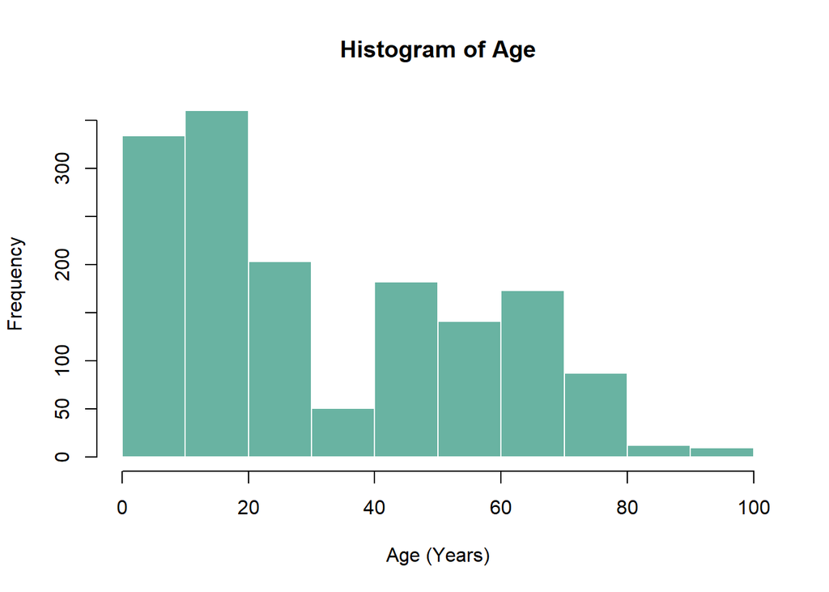

```r
# ....................................................
# Histogram to Visualize Distribution Shape
# ....................................................
hist(vacc_1524$age,
     main = "Histogram of Age",
     xlab = "Age (Years)",
     col = "#69b3a2",
     border = "white")
```

### **🔹 3. Extended Descriptive Summaries**

To produce a comprehensive summary of all variables (especially helpful in surveys or health system datasets), use:

- `describe()` – From `Hmisc`: includes labels, missing %, and stats
- `stat.desc()` – From `pastecs`: full statistical description with skew/kurtosis
- `skim()` – From `skimr`: summary with inline histograms and types

```r
# Install required packages if missing
packages <- c("Hmisc", "pastecs", "skimr")
for (p in packages) {if (!requireNamespace(p, quietly = TRUE)) install.packages(p)}

# Explicitly load the packages
library(Hmisc)     # for describe()
library(pastecs)   # for stat.desc()
library(skimr)     # for skim()

rm (packages)
```

```r
# ------------------------------
# Extended Descriptive Summaries
# ------------------------------

# Hmisc::describe() – Detailed variable summary
describe(vacc_1524[, c("age", "gender", "race")])
```

```
vacc_1524[, c("age", "gender", "race")]

 3  Variables      1553  Observations
--------------------------------------------------------------------------------
age
       n  missing distinct     Info     Mean  pMedian      Gmd      .05
    1553        0       62    0.999    32.42       32    26.76      5.0
     .10      .25      .50      .75      .90      .95
     6.0     12.0     25.0     52.0     68.8     73.0

lowest :  1  2  5  6  7, highest: 76 78 80 85 97
--------------------------------------------------------------------------------
gender
       n  missing distinct
    1553        0        2

Value      Female   Male
Frequency     798    755
Proportion  0.514  0.486
--------------------------------------------------------------------------------
race
       n  missing distinct
    1553        0        5

Value       asian  black native  other  white
Frequency     111     94     13     29   1306
Proportion  0.071  0.061  0.008  0.019  0.841
--------------------------------------------------------------------------------
```

```r
# pastecs::stat.desc() – Full statistics with skewness/kurtosis
stat.desc(vacc_1524$age)
```

```
     nbr.val     nbr.null       nbr.na          min          max        range
1.553000e+03 0.000000e+00 0.000000e+00 1.000000e+00 9.700000e+01 9.600000e+01
         sum       median         mean      SE.mean CI.mean.0.95          var
5.034300e+04 2.500000e+01 3.241661e+01 6.031564e-01 1.183087e+00 5.649777e+02
     std.dev     coef.var
2.376926e+01 7.332432e-01
```

```r
# skimr::skim() – Tidy summary with histograms and data types
skim(vacc_1524[, c("age", "gender", "income")])
```

Data summary

| Name | vacc_1524[, c(“age”, “gen… |
| --- | --- |
| Number of rows | 1553 |
| Number of columns | 3 |
| _______________________ |  |
| Column type frequency: |  |
| factor | 1 |
| numeric | 2 |
| ________________________ |  |
| Group variables | None |

**Variable type: factor**

| skim_variable | n_missing | complete_rate | ordered | n_unique | top_counts |
| --- | --- | --- | --- | --- | --- |
| gender | 0 | 1 | FALSE | 2 | Fem: 798, Mal: 755 |

**Variable type: numeric**

| skim_variable | n_missing | complete_rate | mean | sd | p0 | p25 | p50 | p75 | p100 | hist |
| --- | --- | --- | --- | --- | --- | --- | --- | --- | --- | --- |
| age | 0 | 1 | 32.42 | 23.77 | 1 | 12 | 25 | 52 | 97 | ▇▃▃▃▁ |
| income | 0 | 1 | 108887.58 | 139702.07 | 7361 | 35860 | 75767 | 124775 | 816851 | ▇▁▁▁▁ |

### **🔹 4. Tabulation (Frequencies and Proportions)**

Used for categorical variables like gender, race, or vaccine group:

- `table()` – Basic frequency counts
- `prop.table()` – Row/column proportions
- `addmargins()` – Adds totals to tables
- `xtabs()` – Cross-tabulation formula interface

```r
# --------------------------------------------
# 🔹 Categorical Variable Summary
# --------------------------------------------

# Basic frequency counts for individual vaccine types
table(vacc_1524$vaccine_group)
```

```
          COVID-19          DTP group          Hepatitis                Hib
               144                147                111                 32
               HPV          Influenza                IPV      Meningococcal
                59                811                 47                 50
               MMR Pneumococcal PCV13 Pneumococcal PPV23          Rotavirus
                26                 52                  8                 21
         Varicella             Zoster
                26                 19
```

```r
# Frequency counts for grouped vaccine categories
table(vacc_1524$vacc_group3)
```

```
  Childhood Respiratory       Other
        472         955         126
```

```r
# Proportion of grouped vaccine categories
prop.table(table(vacc_1524$vacc_group3))  # Overall proportions
```

```
  Childhood Respiratory       Other
 0.30392788  0.61493883  0.08113329
```

```r
# Frequency table with row/column totals added
addmargins(table(vacc_1524$vacc_group3))
```

```
  Childhood Respiratory       Other         Sum
        472         955         126        1553
```

```r
# Cross-tabulation between vaccine group and gender
xtabs(~ vacc_group3 + gender, data = vacc_1524)
```

```
             gender
vacc_group3   Female Male
  Childhood      233  239
  Respiratory    511  444
  Other           54   72
```

### **🔹 5. Tidy Summary and Tabulations**

Modern workflows prefer tidy-format summaries using:

- `tabyl()` – From `janitor`: clean frequency tables
- `adorn_totals()`, `adorn_percentages()` – Add percentages and totals
- `count()` – From `dplyr`: group-level counts
- `group_by()` + `summarise()` – Group-wise summary
- `pivot_wider()`, `pivot_longer()` – Reshape tables

The section below demonstrates tabulations using `janitor::tabyl()` and tidyverse functions for grouped summaries and table reshaping.

```r
# --------------------------------------------
# 🔹 Tabulation and Table Reshaping
# --------------------------------------------

# 1. Basic clean frequency table with janitor::tabyl()
vacc_1524 %>%
  tabyl(vacc_group3)
```

```
 vacc_group3   n    percent
   Childhood 472 0.30392788
 Respiratory 955 0.61493883
       Other 126 0.08113329
```

```r
# 2. Add column percentages and total row
vacc_1524 %>%
  tabyl(vacc_group3, gender) %>%
  adorn_percentages("col") %>%
  adorn_totals("row") %>%
  adorn_title("combined")  # Cleaner column names
```

```
 vacc_group3/gender     Female       Male
          Childhood 0.29197995 0.31655629
        Respiratory 0.64035088 0.58807947
              Other 0.06766917 0.09536424
              Total 1.00000000 1.00000000
```

```r
# 3. Group-level count using dplyr::count()
vacc_1524 %>%
  count(vacc_group3, gender)
```

```
  vacc_group3 gender   n
1   Childhood Female 233
2   Childhood   Male 239
3 Respiratory Female 511
4 Respiratory   Male 444
5       Other Female  54
6       Other   Male  72
```

```r
# 4. Group-wise summary using group_by + summarise
vacc_1524 %>%
  group_by(vacc_group3) %>%
  summarise(n = n(), .groups = "drop") %>%
  mutate(prop = n / sum(n))
```

```
# A tibble: 3 × 3
  vacc_group3     n   prop
  <fct>       <int>  <dbl>
1 Childhood     472 0.304
2 Respiratory   955 0.615
3 Other         126 0.0811
```

```r
# 5. Pivot table to wide format (e.g., for display or reporting)
vacc_1524 %>%
  count(vacc_group3, gender) %>%
  pivot_wider(names_from = gender, values_from = n, values_fill = 0)
```

```
# A tibble: 3 × 3
  vacc_group3 Female  Male
  <fct>        <int> <int>
1 Childhood      233   239
2 Respiratory    511   444
3 Other           54    72
```

```r
# 6. Optional: Pivot longer to return to tidy format
vacc_1524 %>%
  count(vacc_group3, gender) %>%
  pivot_wider(names_from = gender, values_from = n, values_fill = 0) %>%
  pivot_longer(-vacc_group3, names_to = "gender", values_to = "count")
```

```
# A tibble: 6 × 3
  vacc_group3 gender count
  <fct>       <chr>  <int>
1 Childhood   Female   233
2 Childhood   Male     239
3 Respiratory Female   511
4 Respiratory Male     444
5 Other       Female    54
6 Other       Male      72
```

### **🔹 6. Cross Tabulations**

Used to explore the relationship between two or more categorical variables.

- `CrossTable()` – From `gmodels`: produces detailed cross-tabs with row %, column %, and counts

```r
# Install and load the gmodels package for cross-tabulation
if (!requireNamespace("gmodels", quietly = TRUE)) {
  install.packages("gmodels")
}
library(gmodels)
```

```r
# ------------------------------
# Cross Tabulation Example
# ------------------------------

# Generate a contingency table between gender and vaccine group
CrossTable(vacc_1524$vacc_group3, vacc_1524$gender,
           prop.r = FALSE,     # Row proportions
           prop.c = TRUE,     # Column proportions
           prop.t = FALSE,    # Overall proportion (optional)
           chisq = TRUE)      # Include chi-square test for independence
```

```
   Cell Contents
|-------------------------|
|                       N |
| Chi-square contribution |
|           N / Col Total |
|-------------------------|


Total Observations in Table:  1553


                      | vacc_1524$gender
vacc_1524$vacc_group3 |    Female |      Male | Row Total |
----------------------|-----------|-----------|-----------|
            Childhood |       233 |       239 |       472 |
                      |     0.375 |     0.396 |           |
                      |     0.292 |     0.317 |           |
----------------------|-----------|-----------|-----------|
          Respiratory |       511 |       444 |       955 |
                      |     0.838 |     0.886 |           |
                      |     0.640 |     0.588 |           |
----------------------|-----------|-----------|-----------|
                Other |        54 |        72 |       126 |
                      |     1.783 |     1.885 |           |
                      |     0.068 |     0.095 |           |
----------------------|-----------|-----------|-----------|
         Column Total |       798 |       755 |      1553 |
                      |     0.514 |     0.486 |           |
----------------------|-----------|-----------|-----------|


Statistics for All Table Factors


Pearson's Chi-squared test
------------------------------------------------------------
Chi^2 =  6.162349     d.f. =  2     p =  0.04590531
```

**🔹 Summary Table: Descriptive Statistics and Tabulation Functions**

| **Task** | **Function** | **Package** |
| --- | --- | --- |
| Basic numeric summaries | `summary()`, `mean()`, `sd()`, `IQR()` | base |
| Percentiles and range | `quantile()`, `range()` | base |
| Skewness / Kurtosis | `skewness()`, `kurtosis()` | e1071, moments |
| Extended profiling | `describe()`, `stat.desc()`, `skim()` | Hmisc, pastecs, skimr |
| Frequency tables | `table()`, `xtabs()`, `prop.table()` | base |
| Clean tables (tidy) | `tabyl()`, `adorn_*()`, `count()` | janitor, dplyr |
| Group summaries | `group_by()` + `summarise()` | dplyr |
| Reshape for tables | `pivot_wider()`, `pivot_longer()` | tidyr |
| Rich cross-tabulation | `CrossTable()` | gmodels |

### **7.2 Saving and Writing Data**

- `write.csv()`, `write_xlsx()`, `saveRDS()`, `write_tsv()`
- Exporting interactive tables with `DT::datatable()`
- Saving and loading the entire R workspace (save.image(), load())

## **PART VI: DATA VISUALIZATION WITH `ggplot2`**

**Visualization Contents and Types Overview**

- **Layers**: Theme, Coordinates, Facets, Statistics, Geometries, Aesthetics, Data
- **Chart Types**: line, histogram, boxplot, bar, area, density, violin, dotplot, ECDF, scatter, bubble, QQ plot
- **Comparative & Multivariate**: faceted plot, pair plot, heatmap, treemap, radar chart, ridgeline plot, forest plot
- **Geospatial Visualization**: choropleth map, point map, heatmap overlay
- **Statistical Overlays**: error bars, confidence intervals, regression lines, smoothers
- **Interactive Visualization**: scatter/line/bar (Plotly), interactive tables (DT), interactive maps (Leaflet), dashboards (Shiny, flexdashboard)

Effective visualizations help uncover patterns, trends, and insights in data. In R, we commonly use the `ggplot2` package for static plots and tools like `plotly`, `DT`, and `leaflet` for interactive dashboards and graphics.

The sections below summarize different types of visualizations and how they fit into analysis workflows.

### **🔹 Visualization Layer Components**

Every ggplot chart is built using multiple composable layers: - **Data**: The dataset to visualize. - **Aesthetics (`aes()`)**: Mappings between variables and visual elements (e.g., x, y, color). - **Geometries (`geom_*`)**: Plot types (e.g., `geom_line()`, `geom_bar()`). - **Statistics (`stat_*`)**: Summaries or transformations (e.g., `stat_smooth()`). - **Facets**: Create multiple plots by group (`facet_wrap()`, `facet_grid()`). - **Coordinates**: Set axis and aspect ratio (`coord_cartesian()`, `coord_flip()`). - **Themes**: Control overall appearance (e.g., `theme_minimal()`, `theme_bw()`).

### **🔹 Common Chart Types**

| **Chart Type** | **Function** | **Used For** |
| --- | --- | --- |
| Line Chart | `geom_line()` | Trends over time |
| Histogram | `geom_histogram()` | Distribution of continuous variables |
| Boxplot | `geom_boxplot()` | Distribution & outliers |
| Bar Plot | `geom_bar()` | Counts or categorical comparison |
| Area Plot | `geom_area()` | Cumulative trends |
| Density Plot | `geom_density()` | Smoothed distribution |
| Violin Plot | `geom_violin()` | Combination of boxplot + density |
| Dot Plot | `geom_dotplot()` | Count-based plots |
| ECDF Plot | `stat_ecdf()` | Cumulative distribution |
| Scatter Plot | `geom_point()` | Bivariate relationships |
| Bubble Plot | `geom_point(aes(size = ...))` | 3-variable comparison using size |

### **🔹 Comparative & Multivariate Visuals**

| **Visual Type** | **Purpose** |
| --- | --- |
| **Faceted Plot** (`facet_wrap`) | Compare subgroups in separate panels |
| **Pair Plot** (`GGally::ggpairs`) | Explore all pairwise relationships |
| **Heatmap** (`geom_tile`, `heatmap()`) | Show intensity using color |
| **Treemap** (`treemapify`) | Hierarchical categories and values |
| **Radar Chart** (`fmsb`) | Compare multivariate profiles |
| **Ridgeline Plot** (`ggridges`) | Distribution comparison across groups |
| **Forest Plot** (`forestplot`, `ggforestplot`) | Confidence intervals and effect sizes |

### **🔹 Geospatial Visualizations**

| **Map Type** | **Function/Use** |
| --- | --- |
| Choropleth Map | Show values by region (e.g., `geom_sf()`, `tmap`) |
| Point Map | Locations with coordinates (e.g., `geom_point()`, `leaflet::addMarkers`) |
| Heatmap Overlay | Density of spatial events (e.g., `leaflet::addHeatmap()`) |

### **🔹 Statistical Enhancements (Overlays)**

- **Error bars**: `geom_errorbar()` for confidence or SD intervals
- **Regression lines**: `geom_smooth(method = "lm")`
- **Trend smoothing**: `geom_smooth()` with `method = "loess"`
- **Labeling**: `geom_text()`, `geom_label()` to annotate plots

This section demonstrates how to visualize breast cancer screening and vaccination data. We’ll walk through common chart types such as line plots, bar charts, boxplots, and faceted views. Each example is designed with annotations and descriptions to aid understanding.

### **🔹 Visualization Layer Components with Examples**

Each chart demonstrates how different `ggplot2` components come together using real health datasets.

```r
# Install if not already installed
if (!requireNamespace("treemapify", quietly = TRUE)) {install.packages("treemapify")}
if (!requireNamespace("ggridges", quietly = TRUE)) {install.packages("ggridges")}
if (!requireNamespace("gganimate", quietly = TRUE)) install.packages("gganimate")
if (!requireNamespace("gifski", quietly = TRUE)) install.packages("gifski")

library(gganimate)
library(gifski)
library(ggridges)
library(dplyr)
library(ggplot2)
library(plotly)
library(treemapify)
library(stringr)  # for str_to_title()
library(tidyr)
```

[output not shown]

[output not shown]

[output not shown]

[output not shown]

**Line Chart – Breast Cancer Screening Trends by Region in Australia**

The example below shows a **line chart** illustrating trends in **breast cancer screening rates** across Australian states from 2016 to 2019.

- Breast cancer screening rates across most Australian states appeared relatively consistent from 2016 to 2018, with minor year-to-year variations.
- A notable decline in screening rates is evident after 2018 and particularly in 2019, coinciding with the early stages of the COVID-19 pandemic

**State-specific Observations:**

- **Tasmania (Tas)** consistently had the highest screening rate, around 60%, but showed a clear decline post-2018.
- The **Northern Territory (NT)** had the lowest rates, around 40%, also experiencing a slight decline during this period.
- Other states (**ACT, NSW, Qld, SA, Vic, WA**) maintained relatively stable rates (around 55%) until 2018, after which a distinct downturn is noticeable, particularly in Western Australia (WA) and Victoria (Vic).

**Impact of COVID-19:**

- The observed decline in breast cancer screening from 2019 onwards aligns with the emergence of the COVID-19 pandemic, which disrupted routine healthcare services globally.

This analysis underscores the importance of maintaining consistent access to healthcare services, particularly preventive screenings, even during periods of significant healthcare disruption.

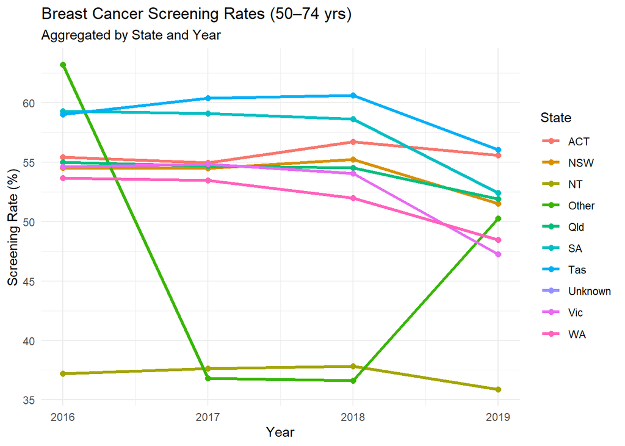

```r
# Visualizing changes in screening rates (50–74 years) over time by state

breast_cancer_data %>%
  group_by(state, year_4digit) %>%  # group by state and year
  summarise(mean_rate = mean(rate50_74, na.rm = TRUE), .groups = "drop") %>%
  ggplot(aes(x = year_4digit, y = mean_rate, color = state)) +  # map axes and color
  geom_line(size = 1.2) +  # trend lines
  geom_point(size = 2) +   # points for each year
  labs(
    title = "Breast Cancer Screening Rates (50–74 yrs)",
    subtitle = "Aggregated by State and Year",
    x = "Year", y = "Screening Rate (%)",  # Axis labels
    color = "State"   # Legend title
  ) +

  theme_minimal()
```

**Histogram – Distribution of Age**  
Displays the frequency of vaccinated individuals by age, with a density line overlay to visualize the distribution shape.

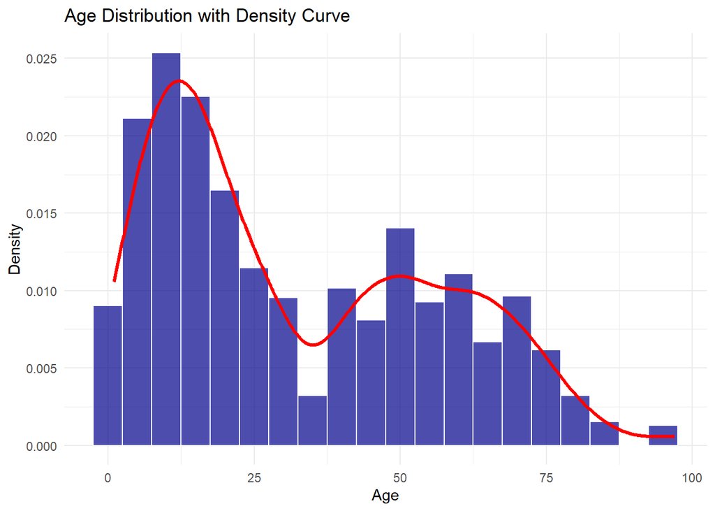

```r
vacc_1524 %>%
  ggplot(aes(x = age)) +
  geom_histogram(aes(y = ..density..), binwidth = 5, fill = "darkblue", color = "white", alpha = 0.7) +
  geom_density(color = "red", size = 1.2) +
  labs(title = "Age Distribution with Density Curve", x = "Age", y = "Density") +
  theme_minimal()
```

**Pie Chart – Proportion by Vaccine Group**  
Shows how vaccine groups are proportionally represented in the dataset. Useful for visualizing categorical outcomes.

In the example below, the pie chart represents the proportion of vaccinations grouped into three categories:

- **Respiratory vaccines** account for the largest proportion, comprising **61%** of all vaccines administered.
- **Childhood vaccines** represent a significant portion as well, making up **30%**.
- The category labeled **Other** includes **8%** of vaccines administered, indicating a smaller but notable group of vaccinations outside the respiratory and childhood classifications.

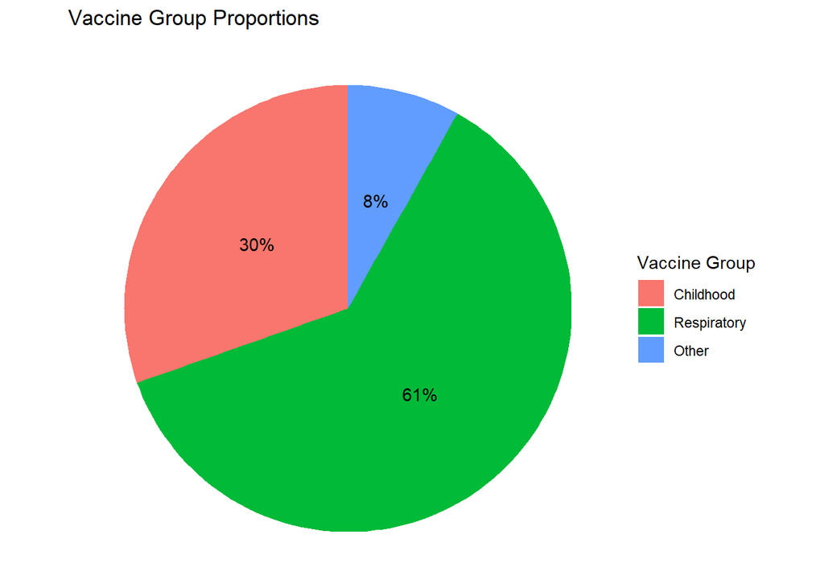

```r
vacc_1524 %>%
  count(vacc_group3) %>%
  mutate(perc = n / sum(n), label = scales::percent(perc)) %>%
  ggplot(aes(x = "", y = perc, fill = vacc_group3)) +
  geom_col(width = 1) +
  coord_polar(theta = "y") +
  geom_text(aes(label = label), position = position_stack(vjust = 0.5)) +
  labs(title = "Vaccine Group Proportions", fill = "Vaccine Group") +
  theme_void()
```

**Bar Plot – Vaccination Count by Vaccine Group**  
This plot compares the absolute count of vaccinations across groups, with horizontal bars for better readability of long labels.

The example below shows a **horizontal bar chart** illustrating the total number of vaccinations administered, grouped into three distinct categories:

- **Respiratory vaccines** clearly represent the largest group, indicating that these vaccines were administered most frequently within the population.
- The **Other** category accounts for the smallest number of vaccinations, suggesting a relatively minor proportion of miscellaneous or specialized vaccines.

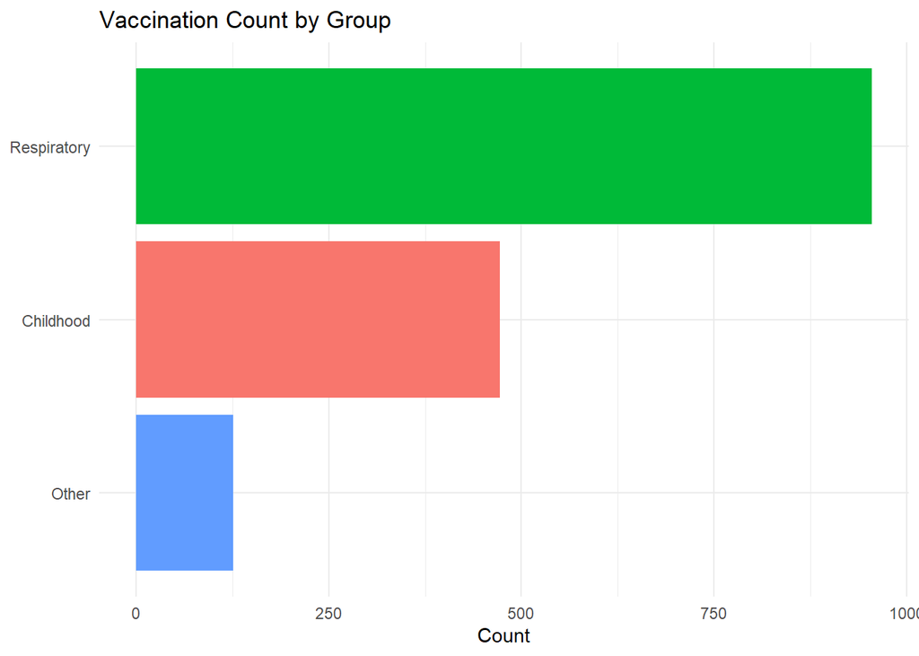

```r
vacc_1524 %>%
  count(vacc_group3) %>%
  ggplot(aes(x = reorder(vacc_group3, n), y = n, fill = vacc_group3)) +
  geom_bar(stat = "identity") +
  coord_flip() +
  labs(title = "Vaccination Count by Group", x = NULL, y = "Count") +
  theme_minimal() +
  theme(legend.position = "none")
```

```
**Implications:**

These patterns may suggest varying public health strategies, demographic factors, or differing healthcare access across racial groups. Understanding these variations can guide targeted healthcare interventions and improve vaccine coverage equity.
```

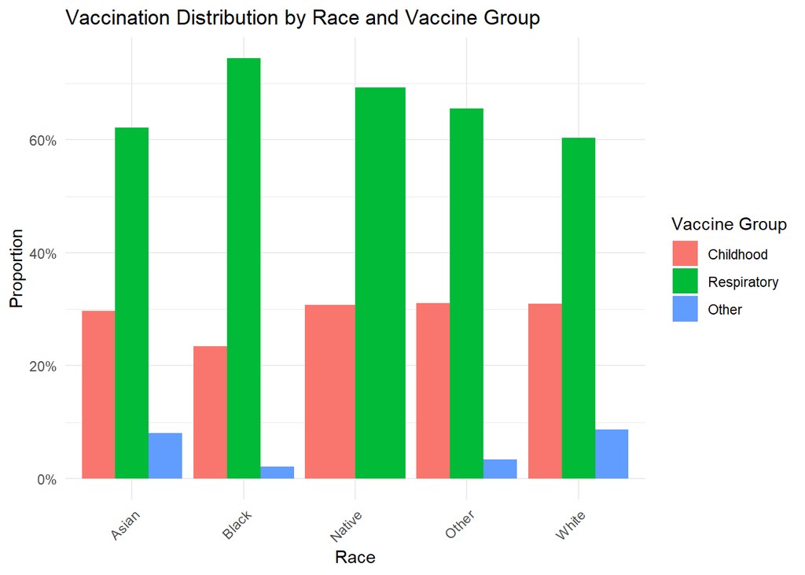

```r
# Prepare data: count vaccinations by race and vaccine group

vacc_1524$race <- tools::toTitleCase(vacc_1524$race)

vacc_summary <- vacc_1524 %>%
  count(race, vacc_group3) %>%
  group_by(race) %>%
  mutate(prop = n / sum(n)) %>%
  ungroup()

ggplot(vacc_summary, aes(x = race, y = prop, fill = vacc_group3)) +
  geom_col(position = "dodge") +
  labs(
    title = "Vaccination Distribution by Race and Vaccine Group",
    x = "Race", y = "Proportion",
    fill = "Vaccine Group"
  ) +
  scale_y_continuous(labels = scales::percent_format()) +
  theme_minimal() +
  theme(axis.text.x = element_text(angle = 45, hjust = 1))
```

```r
rm(vacc_summary)
```

**Stacked Bar Chart – Race by Vaccine Group**

The example below shows a **stacked bar chart** illustrating the number of vaccinations administered, grouped by vaccine type and categorized by racial groups.

- The **White** population received the highest number of vaccinations across all vaccine categories (**Childhood, Other, and Respiratory vaccines**).
- Other racial groups (**Asian, Black, Native, and Other**) also received vaccinations, though in smaller numbers across each vaccine type, indicating ongoing efforts to reach diverse communities.
- **Respiratory vaccines** had the highest total number of vaccinations administered, suggesting these vaccines were a primary focus within the vaccination program.

```
This data helps to illustrate which groups have higher vaccine coverage and highlights the importance of ensuring equitable access and distribution across all communities.
```

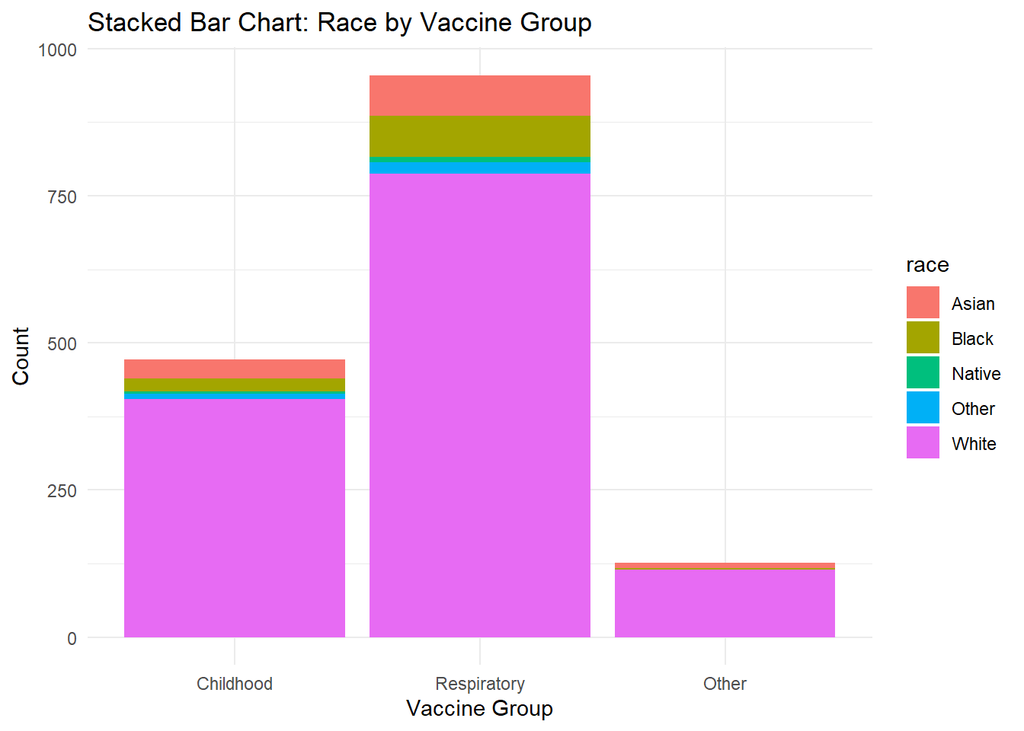

```r
vacc_1524 %>%
  mutate(race = stringr::str_to_title(race)) %>%
  count(vacc_group3, race) %>%
  ggplot(aes(x = vacc_group3, y = n, fill = race)) +
  geom_bar(stat = "identity") +
  labs(title = "Stacked Bar Chart: Race by Vaccine Group", x = "Vaccine Group", y = "Count") +
  theme_minimal()
```

**Boxplot – Age Distribution by Vaccine Group**  
Visualizes how age varies across vaccine groups using standard boxplots.

The example below shows a **box plot** depicting age distribution for three vaccine categories (**Childhood vaccines, Other vaccines, and Respiratory vaccines**):

**Implications:**

This visualization highlights clear age-based targeting for different vaccine categories. Childhood vaccines are expectedly administered primarily to younger populations, while respiratory vaccines predominantly reach older adults. Understanding these age patterns helps to plan targeted public health campaigns and resource allocation effectively.

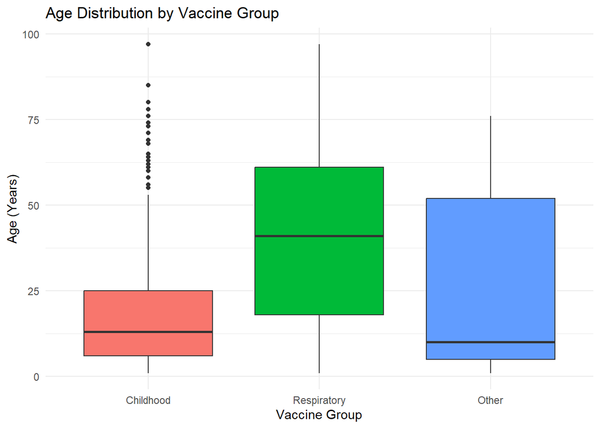

```r
vacc_1524 %>%
  ggplot(aes(x = vacc_group3, y = age, fill = vacc_group3)) +
  geom_boxplot() +
  labs(title = "Age Distribution by Vaccine Group",
       x = "Vaccine Group", y = "Age (Years)") +
  theme_minimal() +
  theme(legend.position = "none")
```

**Boxplot with Jittered (Individual Data) Points**  
Combines summary and raw data by overlaying individual age points on the boxplot.

The example below shows a **boxplot with individual data points (jittered)**, displaying the **age distribution** of individuals across three vaccine groups: **Childhood vaccines, Other vaccines, and Respiratory vaccines**.

- **Childhood vaccines**:
- Most individuals who received childhood vaccines are young, with a median age around 10 years.
- The distribution is tightly concentrated, though some older individuals (outliers) also received these vaccines.
- The data points clearly cluster in younger age ranges, which is expected for this vaccine group.
  - **Respiratory vaccines**:
    - This group has the highest median age, around 40–50 years.
    - The data points are more evenly spread out across a wide age range, with many individuals above 60 years, indicating respiratory vaccines are frequently administered to older populations.

  **Other vaccines**:
  - This group shows a wide range of ages, from infants to older adults.
  - While the median age is still relatively low, the spread is broader compared to childhood vaccines, suggesting this category includes various vaccines administered across different age groups.

  **Implications:**

  By combining summary statistics (boxplot) with individual-level data (dots), this chart offers a clear view of both overall trends and variation in vaccination by age. It confirms that vaccine distribution aligns with age-specific health needs—young children for childhood vaccines, and older adults for respiratory vaccines—while also showing the diversity within each group.

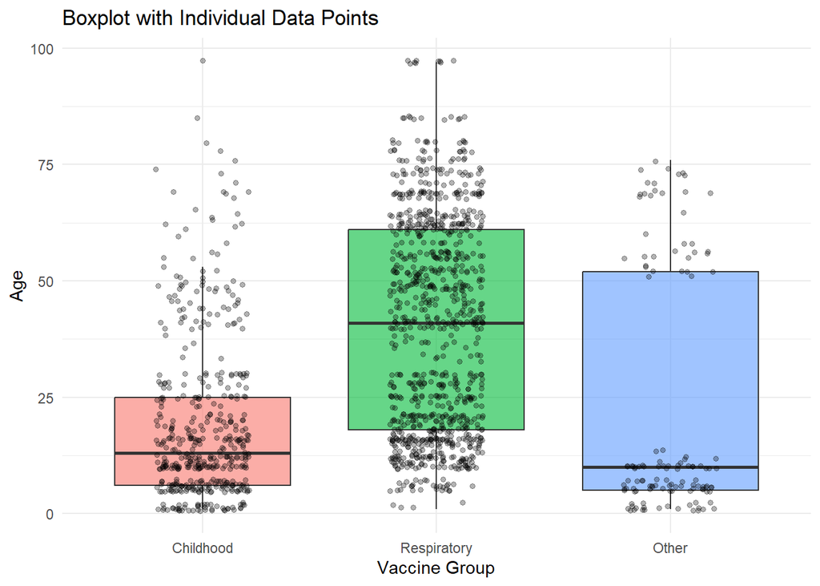

```r
vacc_1524 %>%
  ggplot(aes(x = vacc_group3, y = age, fill = vacc_group3)) +
  geom_boxplot(outlier.shape = NA, alpha = 0.6) +
  geom_point(position = position_jitter(width = 0.2),
             alpha = 0.3, color = "black", size = 1.2) +
  labs(title = "Boxplot with Individual Data Points",
       x = "Vaccine Group", y = "Age") +
  theme_minimal() +
  theme(legend.position = "none")
```

**Boxplot with Violin Overlay**  
Adds a violin plot to visualize the full distribution of ages while preserving boxplot summary stats.

The plot below combines a **boxplot** and **violin plot** to display the age distribution across different vaccine groups: **Childhood vaccines**, **Other vaccines**, and **Respiratory vaccines**.

  **Overall**, this combined plot provides both statistical summaries (via boxplot) and full distribution shapes (via violin plot), helping to clearly distinguish the age-related usage patterns across vaccine types.

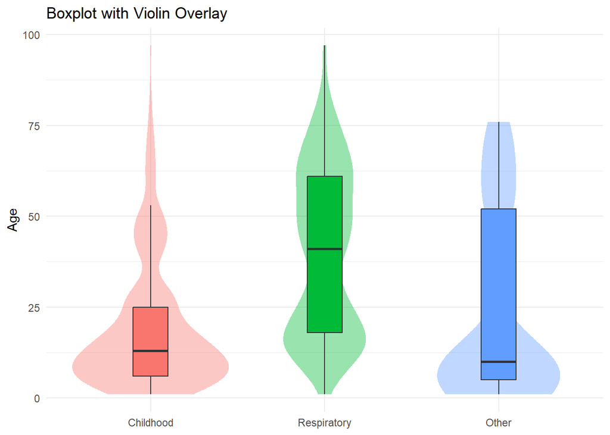

```r
vacc_1524 %>%
  ggplot(aes(x = vacc_group3, y = age, fill = vacc_group3)) +
  geom_violin(alpha = 0.4, color = NA) +
  geom_boxplot(width = 0.2, outlier.shape = NA) +
  labs(title = "Boxplot with Violin Overlay", x = NULL, y = "Age") +
  theme_minimal() +
  theme(legend.position = "none")
```

**Notched Boxplot – Median Comparison**  
Notches allow a rough comparison of medians across groups. Non-overlapping notches suggest a significant difference.

The plot below presents a **notched boxplot** showing the age distribution for each vaccine group—**Childhood vaccines**, **Other vaccines**, and **Respiratory vaccines**.

- The **notches** around the medians provide a visual guide for comparing the central values (medians) across groups. If the notches do not overlap, it suggests that the medians are likely different in a statistically meaningful way.

**Key insights:**

- **Childhood vaccines** show a younger age distribution, with a median age around 10 years and a narrow spread. Outliers indicate a few older individuals also received these vaccines.
- **Respiratory vaccines** are mainly administered to older age groups, with the highest median age among the three categories.
- **Other vaccines** span a wider range of ages, but the median remains lower than that of respiratory vaccines.

**Median Comparison:**

```
Notch went outside hinges
ℹ Do you want `notch = FALSE`?
```

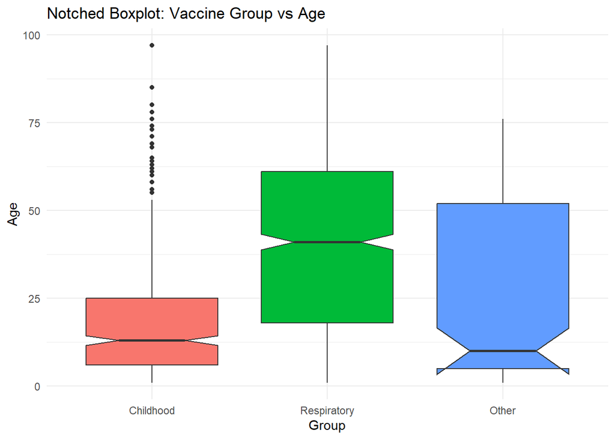

```r
vacc_1524 %>%
  ggplot(aes(x = vacc_group3, y = age, fill = vacc_group3)) +
  geom_boxplot(notch = TRUE) +
  labs(title = "Notched Boxplot: Vaccine Group vs Age", x = "Group", y = "Age") +
  theme_minimal() +
  theme(legend.position = "none")
```

**Faceted Boxplot by Gender**  
Breaks down the age distribution by vaccine group and gender to compare across subgroups.

The plot below shows **boxplots of age distribution** by **vaccine group** (**Childhood**, **Respiratory**, and **Other vaccines**), separated into two panels by **gender** (**Female** and **Male**).

**Key Observations:**

- **Childhood vaccines**:

[output not shown]

- **Respiratory vaccines**:

```
-    This group shows a wide age range in both genders, with median ages around 40–45 years.

-    The distribution is slightly more spread out among males, but the overall trend remains consistent across genders.
```

- **Other vaccines**:

[output not shown]

**Summary:**

This faceted view helps highlight how **age patterns differ by both vaccine group and gender**. While childhood and respiratory vaccine distributions are generally similar across genders, the **“Other” vaccine group shows more variation**, possibly reflecting differences in vaccine eligibility, access, or health needs.

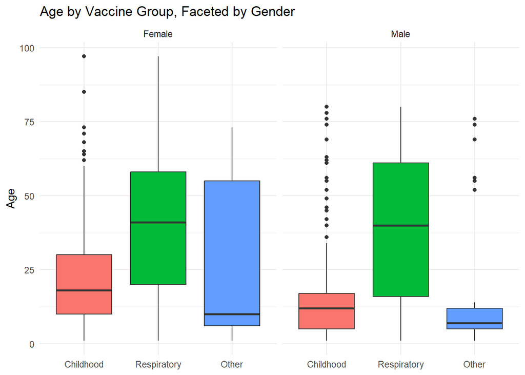

```r
vacc_1524 %>%
  ggplot(aes(x = vacc_group3, y = age, fill = vacc_group3)) +
  geom_boxplot() +
  facet_wrap(~ gender) +
  labs(title = "Age by Vaccine Group, Faceted by Gender", x = NULL, y = "Age") +
  theme_minimal() +
  theme(legend.position = "none")
```

**Ordered Boxplot – by Median Age**  
Reorders vaccine groups by median age to emphasize differences in distribution centrality.

The plot below shows **age distributions by vaccine group**, with the groups reordered by **median age** to highlight differences in central tendency.

**Conclusion:**

By ordering the boxplots by median age, this visual emphasizes the different age profiles targeted by each vaccine group. This approach helps communicate age-related trends in vaccine administration more clearly .

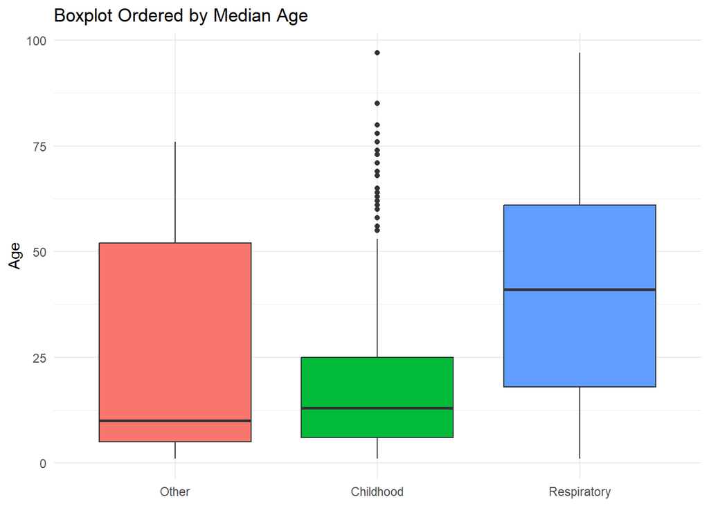

```r
vacc_1524 %>%
  mutate(vacc_group3 = fct_reorder(vacc_group3, age, median, na.rm = TRUE)) %>%
  ggplot(aes(x = vacc_group3, y = age, fill = vacc_group3)) +
  geom_boxplot() +
  labs(title = "Boxplot Ordered by Median Age", x = NULL, y = "Age") +
  theme_minimal() +
  theme(legend.position = "none")
```

**Area Plot – Monthly Vaccination Trends Over Years**  
Uses an area chart to show monthly vaccination volumes over multiple years, stacked by year.

The area chart below displays **monthly vaccination counts** over multiple years (2015–2024), helping visualize seasonal and annual trends in vaccine uptake.

**Key Observations:**

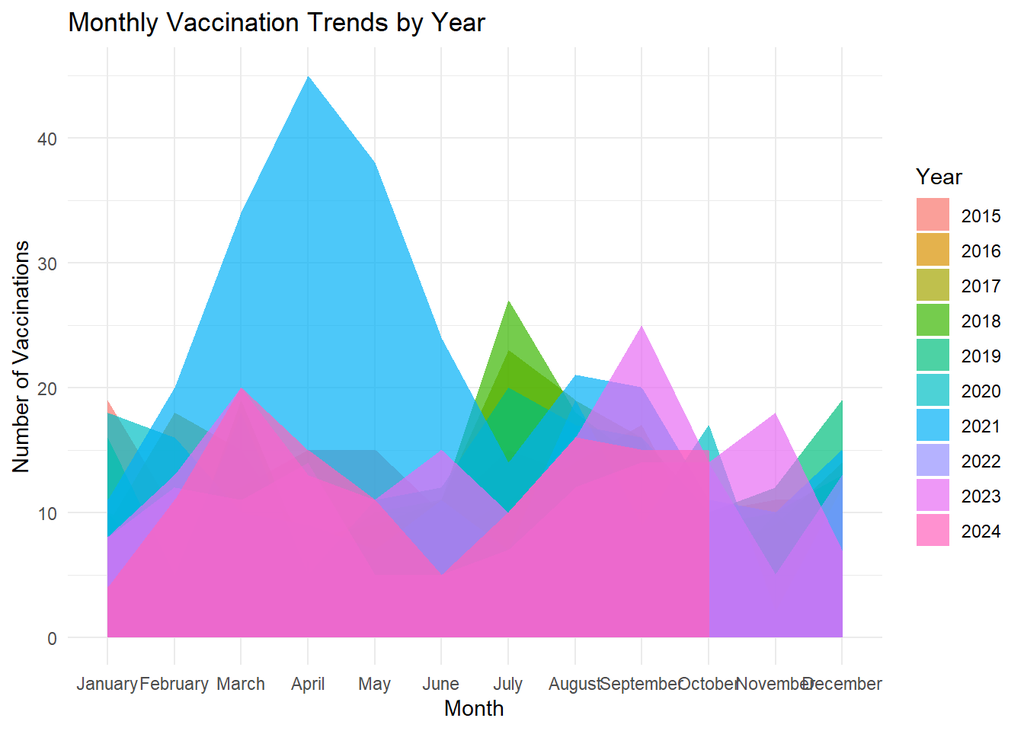

```r
vacc_1524 %>%
  count(vacc_year, vacc_month_name) %>%
  ggplot(aes(x = vacc_month_name, y = n, group = vacc_year, fill = factor(vacc_year))) +
  geom_area(alpha = 0.7, position = "identity") +
  labs(title = "Monthly Vaccination Trends by Year",
       x = "Month", y = "Number of Vaccinations", fill = "Year") +
  theme_minimal()
```

**Faceted Plot – Proportional Vaccination Trends by Group and Race**  
Displays how the proportion of vaccinations among different races changed across years, separately for each vaccine group.

The faceted line plot below shows how the **proportion of vaccinations** among different **racial groups** has changed over time (**2015–2024**), presented separately for each **vaccine group**: **Childhood**, **Respiratory**, and **Other**.

**Key Observations:**

- **Childhood vaccines**:

[output not shown]

- **Other vaccines**:

```
-   Representation is generally lower and more variable across all racial groups.

-    The **White** group maintains a small but steady share throughout most years.

**Interpretation:**
```

This faceted view enables comparisons within and between vaccine types, highlighting potential shifts in **vaccine access**, **uptake**, or **data coverage** by racial group over time. It also suggests where disparities or changes in focus may have occurred, helping to inform more equitable vaccination strategies.

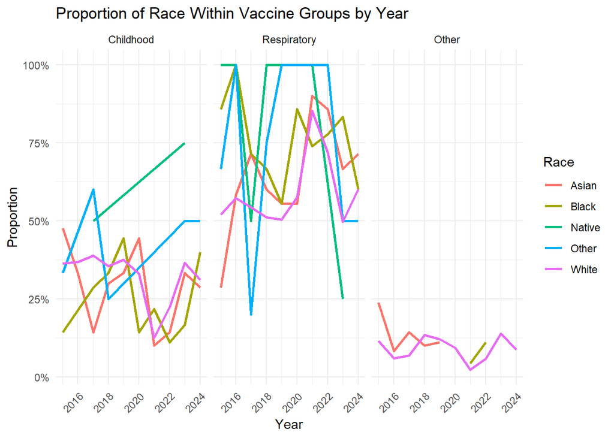

```r
# Prepare data: floor year, count by group, compute proportions within each group

# Clean and count total per race/year (for denominator)
total_by_race_year <- vacc_1524 %>%
  mutate(
    age = as.integer(round(age)),
    vacc_year = as.integer(floor(vacc_year)),
    race = str_to_title(as.character(race))
  ) %>%
  count(vacc_year, race, name = "total_race_year")

#  Count per vaccine group (for numerator), then join
vacc_plot_data <- vacc_1524 %>%
  mutate(
    age = as.integer(round(age)),
    vacc_year = as.integer(floor(vacc_year)),
    race = str_to_title(as.character(race))
  ) %>%
  count(vacc_year, race, vacc_group3, name = "n") %>%
  left_join(total_by_race_year, by = c("vacc_year", "race")) %>%
  mutate(prop = n / total_race_year)

# Plot proportion by race within group
ggplot(vacc_plot_data, aes(x = vacc_year, y = prop, color = race)) +
  geom_line(size = 1) +
  facet_wrap(~ vacc_group3) +
  scale_y_continuous(labels = percent_format()) +
  scale_x_continuous(breaks = pretty(unique(vacc_plot_data$vacc_year))) +
  labs(
    title = "Proportion of Race Within Vaccine Groups by Year",
    x = "Year", y = "Proportion", color = "Race"
  ) +
  theme_minimal() +
  theme(axis.text.x = element_text(angle = 45, hjust = 1))
```

```r
rm(vacc_plot_data, total_by_race_year)
```

**Statistical Overlay – Regression Line on Vaccination Age**  
Adds a linear regression to examine the relationship between income and age at vaccination.

The scatterplot below visualizes the relationship between **income** (horizontal axis) and **age at vaccination** (vertical axis), with a **linear regression line** and confidence band overlaid to summarize the trend.

**Key Observations:**

- The fitted **regression line** shows a **slight negative slope**, suggesting that as income increases, the age at which individuals receive vaccination tends to **decrease modestly**.
- The **confidence band** (shaded region) around the line is relatively narrow, indicating a fair level of certainty in the trend across the central range of income.
- The majority of data points are concentrated in the lower income ranges, while higher income values are more sparsely populated and show greater variability.

```
**Interpretation:**
```

This trend suggests a **possible inverse relationship** between income and vaccination age—individuals with higher income may be more likely to receive vaccines at younger ages. This could reflect differences in healthcare access, awareness, or proactive health behaviors associated with income level.

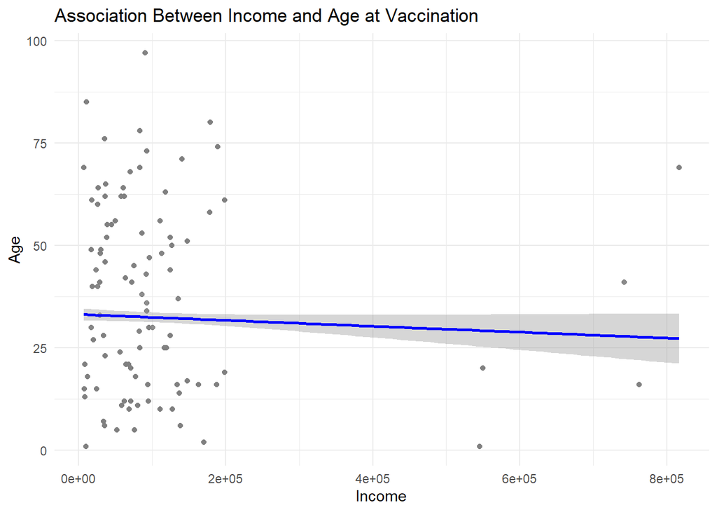

```r
vacc_1524 %>%
  ggplot(aes(x = income, y = age)) +
  geom_point(alpha = 0.3, color = "gray50") +
  geom_smooth(method = "lm", se = TRUE, color = "blue") +
  labs(
    title = "Association Between Income and Age at Vaccination",
    x = "Income", y = "Age"
  ) +
  theme_minimal()
```

**Regression Plot – Age vs Income by Vaccine Group (Log Scale)**  
Adds linear regression and facets by vaccine group. The x-axis is log-scaled to handle skewed income data.

The plot below shows **scatterplots with linear regression lines**, examining the relationship between **income** and **age at vaccination**. The plots are faceted by **vaccine group**: **Childhood**, **Other**, and **Respiratory**. The x-axis uses a **logarithmic scale** to better handle the skewed distribution of income.

**Key Observations:**

- **Childhood vaccines**:

```
-    A **slight negative trend** is observed, indicating that as income increases, age at vaccination tends to decrease slightly.

-    This may reflect earlier or more timely vaccinations among higher-income individuals for childhood vaccines.
```

- **Other vaccines**:

```
-   The regression line is nearly flat with a wide confidence interval, suggesting **no strong or consistent relationship** between income and age at vaccination in this group.

-    This likely reflects diverse vaccine purposes and use across a broad age and income range.
```

- **Respiratory vaccines**:

```
-   A **mild negative trend** is also seen here, where higher-income individuals may receive respiratory vaccines at slightly younger ages.

-    However, the relationship is subtle and the confidence interval overlaps considerably with the regression line.

**Interpretation:**
```

While the strength of association varies across groups, both the childhood and respiratory vaccine panels suggest a small trend where **higher income is associated with younger age at vaccination**. This may be related to differences in **access**, **preventive health behaviors**, or **healthcare utilization** by income level.

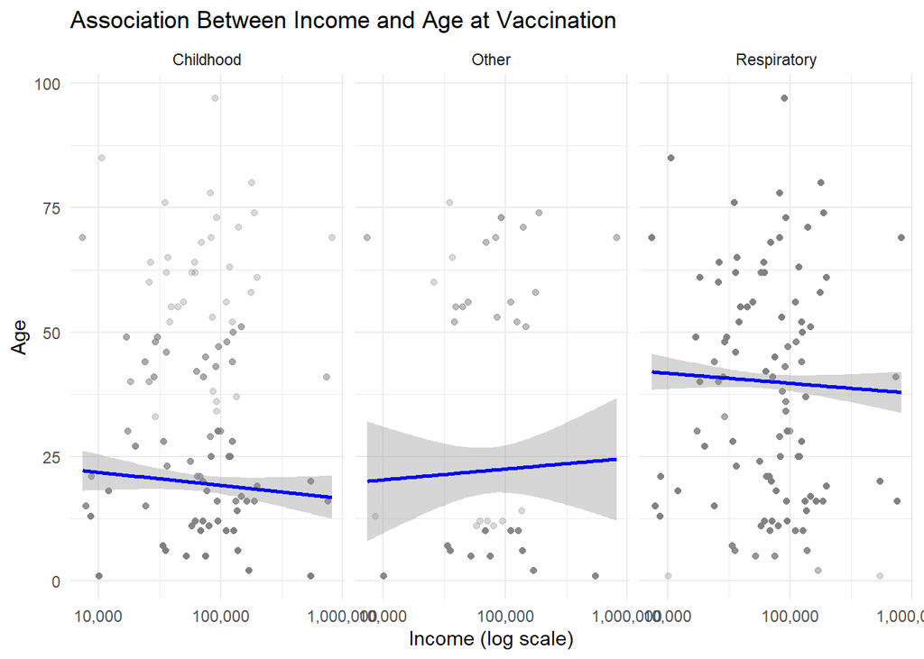

```r
vacc_1524 %>%
  mutate(vacc_group3 = str_to_title(vacc_group3)) %>%
  ggplot(aes(x = income, y = age)) +
  geom_point(alpha = 0.3, color = "gray50") +
  geom_smooth(method = "lm", se = TRUE, color = "blue") +
  scale_x_log10(labels = scales::comma_format()) +
  facet_wrap(~ vacc_group3) +
  labs(
    title = "Association Between Income and Age at Vaccination",
    x = "Income (log scale)", y = "Age"
  ) +
  theme_minimal()
```

**ECDF – Age at Vaccination**

The empirical cumulative distribution function (ECDF) shows the proportion of individuals vaccinated at or below each age. This helps visualize the age distribution in a cumulative way.

The plot below presents shows the **cumulative proportion** of individuals who received a vaccination at or below each age.

**Interpretation:**

The ECDF provides an intuitive way to understand the **distribution of vaccination ages**. It highlights that most vaccinations occur in **childhood and early adulthood**, with fewer individuals vaccinated later in life. This cumulative view complements histograms and boxplots by showing the proportion of individuals affected up to each age.

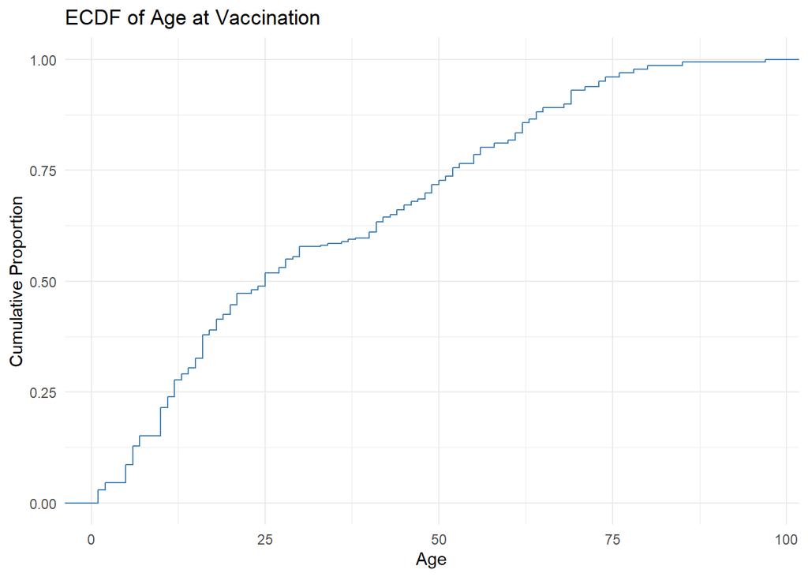

```r
vacc_1524 <- vacc_1524 %>% filter(income > 0, !is.na(age))

vacc_1524 %>%
  ggplot(aes(x = age)) +
  stat_ecdf(geom = "step", color = "steelblue") +
  labs(title = "ECDF of Age at Vaccination", x = "Age", y = "Cumulative Proportion") +
  theme_minimal()
```

**Treemap – Vaccination by Race and Vaccine Group**

This treemap visualizes the distribution of vaccinations by race and vaccine group. Larger areas indicate more individuals within each combination.

The treemap below displays the **distribution of vaccinations** across **racial groups**, further categorized by **vaccine group** (Childhood, Respiratory, and Other). Each rectangle represents a combination of race and vaccine type, with **area size corresponding to the number of individuals** vaccinated.

**Key Observations:**

- The **White** population accounts for the **largest share overall**, with:

```
-    **788 individuals (50.7%)** in the **Respiratory** vaccine group.

-    **404 individuals (26.0%)** in the **Childhood** vaccine group.

-    **114 individuals (7.3%)** in the **Other** vaccine group.
```

- Other racial groups have smaller shares:

```
-    **Black** individuals make up a modest proportion across groups, particularly **4.5%** in the Respiratory group and **1.4%** in Childhood vaccines.

-    **Asian** individuals represent **4.4%** of Respiratory vaccines and **2.1%** of Childhood vaccines.

-    **Native** and **Other** groups have minimal representation overall.

**Interpretation:**
```

This treemap visually emphasizes the dominant contribution of the White population across all vaccine types, especially for respiratory vaccines. It also illustrates disparities in representation among racial groups, which can be important for assessing **equity in vaccine access**, **uptake**, and **program targeting**.

```r
# Cross-platform “new device”:
dev.new(width = 8, height = 6)

p <- vacc_1524 %>%
  count(race, vacc_group3) %>%
  mutate(race = str_to_title(race)) %>%
  ggplot(aes(area = n, fill = vacc_group3, label = race)) +
  geom_treemap() +
  geom_treemap_text(colour = "white", place = "centre", grow = TRUE) +
  labs(
    title = "Treemap: Vaccination by Race and Vaccine Group",
    fill  = "Vaccine Group"
  ) +
  theme_minimal()

print(p)

rm (p)
```

[output not shown]

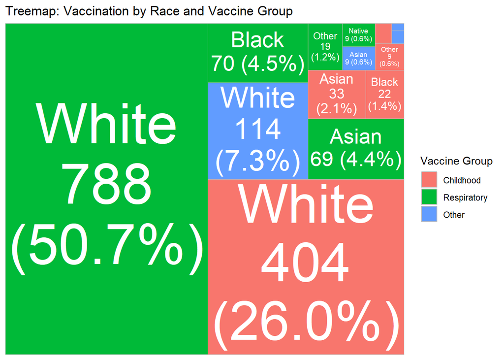

```r
#  Treemap - with Labels Showing Counts and Proportions by Race and vaccine Group
vacc_1524 %>%
  count(race, vacc_group3) %>%
  mutate(
    race = str_to_title(race),
    total = sum(n),
    proportion = n / total,
    label_text = paste0(race, "\n", n, " (", percent(proportion, accuracy = 0.1), ")")
  ) %>%
  ggplot(aes(area = n, fill = vacc_group3, label = label_text)) +
  geom_treemap() +
  geom_treemap_text(colour = "white", place = "centre", grow = TRUE, reflow = TRUE) +
  labs(
    title = "Treemap: Vaccination by Race and Vaccine Group",
    fill = "Vaccine Group"
  ) +
  theme_minimal()
```

**Correlation Heatmap – Numeric Variables**

This heatmap displays Pearson correlation coefficients between selected numeric variables. Strong positive or negative values help identify relationships worth further analysis.

The heatmap below displays **Pearson correlation coefficients** between selected numeric variables: **age**, **income**, **healthcare expenses**, and **healthcare coverage**. Correlation values range from **-1 to 1**, where values closer to ±1 indicate stronger relationships.

**Key Observations:**

- **Age and healthcare coverage** show a **strong positive correlation** (**0.65**), suggesting that as individuals age, they are more likely to have greater healthcare coverage.
- **Age and healthcare expenses** are also **positively correlated** (**0.66**), indicating that older individuals tend to incur higher healthcare costs.
- **Healthcare coverage and healthcare expenses** show a **moderate positive correlation** (**0.44**), which may reflect that those with more coverage also utilize healthcare services more frequently or thoroughly.
- **Income** is **not strongly correlated** with any other variable in this set, with the highest being a negligible **0.02** with healthcare coverage and a slightly negative value with age (**-0.04**) and expenses (**-0.05**).

```
**Interpretation:**
```

This heatmap highlights potential relationships that may inform further analysis—especially the connections between **age, coverage, and expenses**. In contrast, **income appears relatively independent** of the other variables in this dataset.

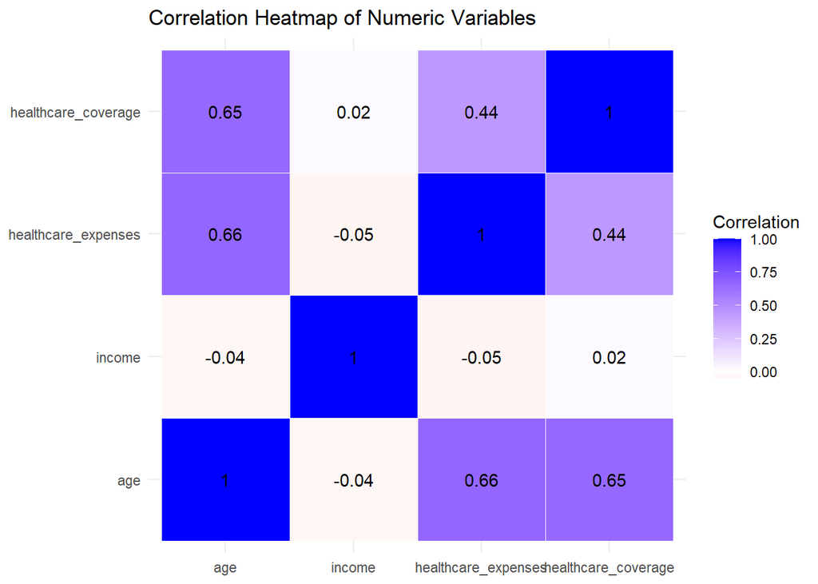

```r
numeric_vars <- vacc_1524 %>%
  select(age, income, healthcare_expenses, healthcare_coverage) %>%
  na.omit()

cor_matrix <- round(cor(numeric_vars), 2)

as.data.frame(as.table(cor_matrix)) %>%
  rename(Var1 = Var1, Var2 = Var2, Correlation = Freq) %>%
  ggplot(aes(x = Var1, y = Var2, fill = Correlation)) +
  geom_tile(color = "white") +
  geom_text(aes(label = Correlation), color = "black") +
  scale_fill_gradient2(low = "red", high = "blue", mid = "white", midpoint = 0) +
  labs(title = "Correlation Heatmap of Numeric Variables", x = NULL, y = NULL) +
  theme_minimal()
```

**Ridgeline Plot – Age by Vaccine Group**

This ridgeline plot shows the age distribution for each vaccine group. It highlights where age densities differ across categories.

The ridgeline plot below shows **age distributions** for three vaccine groups: **Childhood**, **Other**, and **Respiratory**. Each layer represents the **density of ages** within a vaccine category, allowing for visual comparison of where individuals are most commonly vaccinated within each group.

```
**Interpretation:**
```

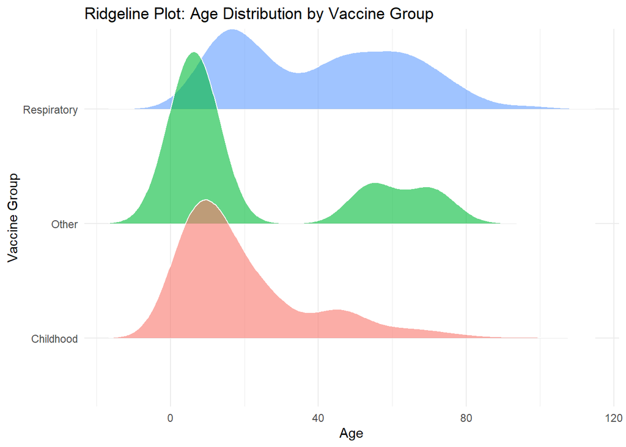

```r
vacc_1524 %>%
  mutate(vacc_group3 = stringr::str_to_title(vacc_group3)) %>%
  ggplot(aes(x = age, y = vacc_group3, fill = vacc_group3)) +
  geom_density_ridges(scale = 1.5, alpha = 0.6, color = "white") +
  labs(title = "Ridgeline Plot: Age Distribution by Vaccine Group", x = "Age", y = "Vaccine Group") +
  theme_minimal() +
  theme(legend.position = "none")
```

**Interactive Plot – Income vs Age by Race**

This interactive scatter plot shows the relationship between income and age, colored by race. Hovering reveals more details including group and income.

```r
p <- vacc_1524 %>%
  mutate(race = stringr::str_to_title(race)) %>%
  ggplot(aes(x = income, y = age, color = race,
             text = paste("Race:", race,
                          "<br>Group:", vacc_group3,
                          "<br>Income:", income,
                          "<br>Age:", age))) +
  geom_point(alpha = 0.6) +
  geom_smooth(method = "loess", se = FALSE, color = "gray30") +
  labs(title = "Interactive: Income vs Age by Race",
       x = "Income", y = "Age", color = "Race") +
  theme_minimal() +
  theme(legend.position = "bottom")

ggplotly(p, tooltip = "text")
```

[interactive chart not shown]

```r
rm(p)
```

**Animation – Vaccination Trends Over Years**

This animation shows how vaccination counts across vaccine groups change over time. It helps spot temporal trends and emerging patterns.

```r
anim_plot <- vacc_1524 %>%
  mutate(vacc_year = as.integer(floor(vacc_year))) %>%
  count(vacc_year, vacc_group3) %>%
  ggplot(aes(x = vacc_group3, y = n, fill = vacc_group3)) +
  geom_col(show.legend = FALSE) +
  labs(title = 'Year: {frame_time}', x = 'Vaccine Group', y = 'Count') +
  theme_minimal() +
  transition_time(vacc_year) +
  ease_aes('linear')

anim_file <- tempfile(fileext = ".gif")
anim <- animate(anim_plot, nframes = 100, fps = 10, renderer = gifski_renderer(anim_file))
# print(anim)

rm(anim_plot, anim_file, anim)
```

**Animation – Breast Cancer Screening Uptake by State**

This animated bar chart shows breast cancer screening uptake over time for each Australian state. It uses faceting to compare regional trends.

```r
breast_anim <- breast_cancer_data %>%
  filter(!state %in% c("Other", "Unknown")) %>%
  mutate(year_4digit = as.integer(year_4digit)) %>%
  group_by(state, year_4digit) %>%
  summarise(total_screened = sum(part50_74, na.rm = TRUE), .groups = "drop") %>%
  ggplot(aes(x = year_4digit, y = total_screened, fill = state)) +
  geom_col(show.legend = FALSE) +
  facet_wrap(~ state) +
  labs(title = 'Year: {frame_time}', x = 'Year', y = 'Women Screened (50–74 yrs)') +
  theme_minimal() +
  transition_time(year_4digit) +
  ease_aes('linear')

screening_gif <- tempfile(fileext = ".gif")
anim_screen <- animate(breast_anim, nframes = 100, fps = 10, renderer = gifski_renderer(screening_gif))
# print(anim_screen)

rm(breast_anim, screening_gif, anim_screen)
```

### **🔹 Formatting, themes and fonts of figures**

**Heatmap – Number of Vaccinations by Month and Weekday** Highlights vaccination activity patterns by day of week and month. Darker tiles represent higher counts.

The heatmap below demonstrates the **number of vaccinations administered** across **each day of the week** and **each calendar month**. Color intensity indicates the relative number of vaccinations, with darker red representing higher uptake and pale yellow representing lower activity.

```
**Interpretation:**
```

The plot reveals both **seasonal** and **weekly rhythms** in vaccination behavior. Recognizing these patterns can guide better **scheduling of clinics**, **resource planning**, and **public messaging** to align with high-demand periods and improve overall vaccine accessibility.

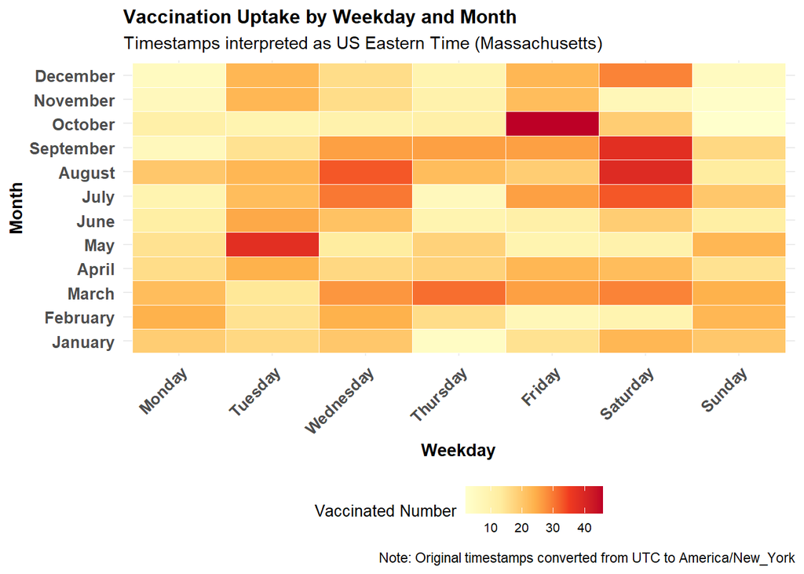

```r
# ................Without  Adding the long Title ........................................................
# ..............................................................................................

# --- Order weekday and month factors for proper axis display ---
# --- Convert original vaccination date to Eastern Time (Massachusetts local time) ---
# Assumes vacc_date is POSIXct or character in UTC or local system time
vacc_1524 <- vacc_1524 %>%
  mutate(
    vacc_datetime_et = with_tz(as.POSIXct(vacc_date, tz = "UTC"), tzone = "America/New_York"),  # Adjust timezone to Eastern Time
    vacc_weekday = wday(vacc_datetime_et, label = TRUE, abbr = FALSE),                          # Extract weekday (e.g., Monday)
    vacc_month_name = month(vacc_datetime_et, label = TRUE, abbr = FALSE)                       # Extract month (e.g., January)
  )

# --- Order weekday and month factors for proper axis display ---
vacc_1524 <- vacc_1524 %>%
  mutate(
    vacc_month_name = factor(vacc_month_name, levels = month.name),  # Ensure months are in calendar order
    vacc_weekday = factor(vacc_weekday, levels = c("Monday", "Tuesday", "Wednesday", "Thursday", "Friday", "Saturday", "Sunday"))  # Ensure weekdays are in logical order
  )

# --- Create heatmap of vaccination counts by weekday and month ---
vacc_1524 %>%
  count(vacc_weekday, vacc_month_name) %>%  # Count number of vaccinations by weekday and month
  ggplot(aes(x = vacc_weekday, y = vacc_month_name, fill = n)) +     # Map weekday to x-axis, month to y-axis, and fill by count
  geom_tile(color = "white") +                                       # Draw heatmap tiles with white border for readability
  scale_fill_gradientn(                                              # Use custom yellow-to-red color scale
    colors = c("#ffffcc", "#ffeda0", "#feb24c", "#f03b20", "#bd0026"),
    breaks = scales::pretty_breaks(n = 5),                           # Auto-select 5 good breakpoints for legend
    name = "Vaccinated Number"                                       # Legend title
  ) +
  labs(
    title = "Vaccination Uptake by Weekday and Month",               # Plot title
    subtitle = "Timestamps interpreted as US Eastern Time (Massachusetts)",  # Timezone context
    x = "Weekday", y = "Month", fill = "Vaccinated Number",          # Axis and legend labels
    caption = "Note: Original timestamps converted from UTC to America/New_York"
  ) +
  theme_minimal() +
  theme(
    text = element_text(family = "Times New Roman"),                 # Font style
    legend.position = "bottom",                                      # Move legend below the plot
    axis.text.x = element_text(angle = 45, hjust = 1, size = 10, face = "bold"),  # X-axis label formatting
    axis.text.y = element_text(size = 10, face = "bold"),            # Y-axis label formatting
    axis.title.x = element_text(face = "bold", size = 11),
    axis.title.y = element_text(face = "bold", size = 11),
    plot.title = element_text(size = 12, face = "bold"),
    legend.title = element_text(size = 10),
    legend.text = element_text(size = 8)
  )
```

```r
# Use figure title below to render in Quarto or Rmarkdown
#"Figure XX: Vaccination uptake by weekday and month among individuals aged 15–24, 2016–2024."
```